# Derecho Civil

Lucas Fernandez

# 1. Teoría de la Norma

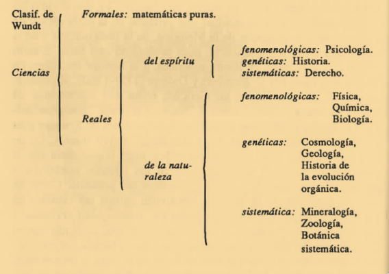

## Clasificación del Derecho

- **Derecho Natural**: es la expresión de los primeros principios de justicia que rigen las relaciones de los hombres en sociedad, determinan las facultades que a cada uno pertenecen de conformidad con el orden natural, y sirven de fundamento a toda regulación positiva de la convivencia humana.
- **Derecho Positivo**: es el conjunto de normas de conducta bilaterales, imperativas y coactivas que regulan efectivamente la conducta de las personas en una sociedad con el objetivo de establecer un ordenamiento justo de la convivencia.

## Fuentes del Derecho

Derecho, para estos efectos, debe ser entendido como *derecho objetivo y positivo*, en sentido de sistema de normas y decisiones impuestas y tuteladas por el poder social. Por otro lado, la fuente del derecho subjetivo es en último término el **derecho objetivo**, el orden natural o positivo.

- **fuentes materiales** = son todos los factores que de forma directa o indirecta concurren en el nacimiento del derecho. Por fuente material *directa* se entiende la sociedad por cuanto en ella se tiene origen la costumbre jurídica, los órganos legislativos, que dan nacimiento a la ley, y los tribunales de justicia, que generan sentencias. Por fuente material *indirecta* se entiende todos aquellos elementos que de forma más o menos remota influye en el nacimiento o en la transformación del Derecho como los principios generales del derecho, las doctrinas religiosas, filosóficas y morales, los factores económicos-sociales, la labor de los juristas, las guerras, las revoluciones, el progreso técnico.
- **fuentes formales** = son las formas en que el Derecho Positivo está contenido y se manifiesta en la vida social, se trata de la forma de expresión del derecho: la ley, la costumbre, las sentencias, la opinión de algunos tratadistas (doctrina) y los tratados internacionales.

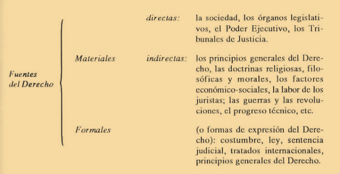

## La Norma

Las normas que tienen por finalidad regular la conducta de la persona tienen por fin realizar valores. Pueden ser clasificadas de diversas maneras, siendo la clasificación más común: - Normas de **trato social**, las cuales tienen como fundamento la buena educación, decoro, protocolo o cortesía. - Normas **morales**, las cuales regulan la conducta libre de la persona que tienen por finalidad la trascendencia del ser conforme a su cosmovisión. - Normas **jurídicas**, las cuales pasaremos a estudiar en seguida.

### La norma jurídica

Mandato dirigido a toda persona que viva en sociedad y mediante el cual, bajo amenaza de sanción, se le conmina a observar una determinada conducta positiva o negativa. Además, tiene por finalidad: a) asegurar la **convivencia pacífica**; y b) **proteger sus intereses** materiales y espirituales. Pacheco. “Es una norma de conducta exterior, bilateral, imperativa y coercitiva que regula la conducta de las personas con el fin de establecer un ordenamiento justo de convivencia humana”.

### ¿Qué diferencia existe entre una ley y una norma?

Según Pacheco, el concepto de normas es más **amplio**, dado que la norma puede expresarse también a través de la costumbre y de las sentencias de los tribunales de justicia. En segundo lugar, la ley requiere, necesariamente de un **legislador, promulgación y vigencia**.

### Clasificación de las normas jurídicas

- Normas de Derecho Público y de Derecho Privado: Son de derecho público aquellas en que existe una relación de subordinación entre las partes, Estado y personas. En las de derecho privado existe una relación de igualdad entre las partes, que puede ser incluso el Estado una de ellas pero actuando como un privado.
- Normas de Orden público y de Orden privado: Las normas de orden público existe un interés superior que se resguarda por lo que no pueden ser disponibles por las partes, es decir, no son derogables ni renunciables por ellas. Las normas de orden privado están puestas en beneficio de las personas y ellas pueden renunciar y disponer cuando así lo quieran. art. 12 CC

### Características de las normas jurídicas

- *Exterioridad*: A la norma jurídica le preocupa la acción humana sólo desde el momento en que ella se ha **exteriorizado**.
- *Bilateralidad*: las normas jurídicas imponen deberes y correlativamente conceden facultades.
- *Determinación*: la norma jurídica generalmente se presenta con un contenido fijo cierto y reconocible. En su defecto, su sentido debe determinar su verdadero alcance.
- *Imperatividad*: Es de la esencia de toda norma jurídica el **ordenar** la realización o la abstención de una determinada conducta. Las primeras se denominan: normas jurídicas imperativas y las segundas, prohibitivas.

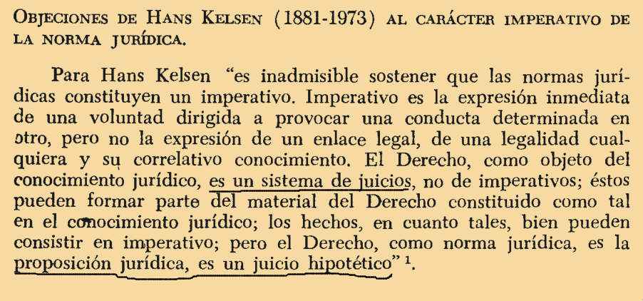

- *Coactividad*: La norma jurídica constituye un imperativo que es susceptible de ser impuesto coactivamente.
- *Finalidad*: Que busca establecer un ordenamiento justo por el cual se pueda lograr el bien común.

## 1.1. Teoría de la Ley

### Concepto

Planiol. “Es una regla social obligatoria, establecida con carácter de permanente por la autoridad pública, y sancionada por la fuerza”.

- Conceptos legales

  art. 1 CC La ley es una declaración de la voluntad soberana que manifestada en la forma prescrita por la CPR, manda prohíbe o permite.

  art. 63 Sólo son materias de ley: Nº 20, toda otra norma de carácter general y obligatoria que estatuya las bases esenciales de un ordenamiento jurídico.

### Clasificación

1. Normativas, Modificatorias, Interpretativas - prohibitivas

   Contiene un mandato de no hacer algo y no lo permite bajo ninguna circunstancia

   art. 10 los actos que prohíbe la ley son nulos y de ningún valor (absoluta), excepto que el legislador haya asignado otra sanción
- imperativas

  Son las que imponen la obligación de hacer algo o el cumplimiento de un requisito.
  - sanción
    - orden público

      Nulidad absoluta o relativa
    - interés privado

      Sera generalmente la responsabilidad
- permisivas

  Son aquellas que confieren un derecho que queda entregado al arbitrio del titular, y otorgan a el, los medios para obtener el reconocimiento de su derecho o la indemnización de los perjuicios que le acarrea su desconocimiento.

### Efectos en el tiempo

art. 6 La ley no obliga sino una vez promulgada en conformidad a la CPR y publicada conforme a las normas establecidas en los art. 7 y 8 CC.

art. 9 Sólo puede disponer para lo futuro y no tendrá jamás efecto retroactivo

- La retroactividad en materia penal

  art. 19 Nª 3.8 CPR Ningún delito se castigará con otra pena que la que señale una ley promulgada con anterioridad a su perpetración, a menos que una nueva ley favorezca al afectado

  art. 18.2 CP Si la ley que exima el hecho de toda pena o le aplique una menos rigurosa se promulgare después de ejecutoriada la sentencia sea que se haya o no cumplido el TRB que hubiere pronunciado dicha sentencia, en 1ª o única deberá modificarla de oficio o a petición de parte
- La retroactividad en materia civil

  Se encuentra principalmente limitada por el art. 19 Nª 24. Nadie pueden en caso alguno, **ser privado de su propiedad**, **del bien sobre que recae** o de **alguno de los atributos o facultades** esenciales del dominio, sino en virtud de una **ley** general o especial que **autorice la expropiación** por causa de **utilidad pública o de interés nacional**, calificada por el juez.
- Ley de Efecto Retroactivo de las Leyes

  Tiene como objetivo decidir los conflictos que resultaren de la aplicación de leyes dictadas en diversas épocas y se inspira en la teoría de los derechos adquiridos y meras expectativas.
  - Derechos adquiridos

    Derecho que por un hecho o acto del hombre o solo ministerio de la ley se ha incorporado al patrimonio, también se entiende por la facultad legalmente ejercida.
  - Meras expectativas

    Derecho no incorporado al patrimonio o, facultad no ejercida legalmente
- Ultractividad de la ley

  art. 22 LERL “en todo contrato se entenderán incorporadas las leyes vigentes al tiempo de su celebración”. Es decir, que pese a la modificación de las leyes, aquellas que se entendían incorporadas al contrato permanecerán vigentes.

### Efectos en el territorio

- Territorialidad

  art. 14 CC “la ley es obligatoria para todos los habitantes de la república, incluso los extranjeros”.
- Qué se entiende por territorio?
  - Es un concepto geográfico por el cual el Estado ejerce su jurisdicción, el cual se encuentra delimitado por sus fronteras, las posesiones chilenas en la Antártica (Territorio Chileno Antártico) y en Oceanía (Isla de Pascua)
    - Territorio terrestre

      El cual comprende el suelo y subsuelo
    - Espacio aéreo

      Consiste en la porción atmosférica terrestre
    - Espacio marítimo

      Consiste en la prolongación del espacio terrestre haca el mar y comprende:
      1. el mar territorial, como extensión de soberanía que va desde la costa hasta las 12 millas marinas
      2. zona contigua, en que el Estado ejerce jurisdicción y se extiende hasta las 24 millas marinas
      3. mar patrimonial, que es una zona económica exclusiva de 200 millas
    - Espacio jurídico

      Consisten en lugares que por los tratados internacionales y la costumbre internacional reconocen como parte de la jurisdicción estatal.
- Extraterritorialidad
  - aplicación de la ley chile fuera del territorio de Chile

    Sólo produce efecto respecto de los chilenos sólo respecto a las siguientes materias:
    1. art. 15 “a las leyes patrias que reglan las obligaciones y derechos civiles, permanecerán los chilenos, no obstante su residencia o domicilio en país extranjero”
    2. En lo relativo al estado de las personas y su capacidad para ejecutar ciertos actos, que hayan de tener efecto en Chile.
    3. En las obligaciones y derechos que nacen de las relaciones de familia, pero sólo respecto de sus cónyuges y parientes chilenos
  - aplicación de ley extranjera en Chile
  1. art. 16 CC da valor a las estipulaciones contenidas en los contratos otorgados válidamente en país extranjero (ley del contrato = se entienden incorporadas a él todas la leyes vigentes en ese momento, en territorio extranjero).
     - Excepción o salvedad

       Sin perjuicio que sus efectos se arreglan a las leyes chilenas.
  2. art. 955 inc. 2 establece que la sucesión se rige por la ley del domicilio en que se abre, por lo que la sucesión de una persona que muere en el extranjero se rige por las leyes de ese país.
  - Excepción o salvedad
    1. respecto a los bienes situados en Chile que forman parte del haber de la sucesión
    2. art. 998 tendrán los chilenos a título de herencia, la porción conyugal o de alimentos los mismos derechos que según las leyes chilenas les correspondería.

### Interpretación de la Ley

Consiste en fijar su verdadero sentido y alcance, para lo cual se ha establecido un conjunto de actividades indispensables para aplicar el derecho a través de un sistema de interpretación reglada en los art. 19 a 24 CC Elementos de interpretación:

- Elemento gramatical

  Implica el análisis de la semántica y de la sintaxis del precepto. Señala el art. 19: "cuando el sentido de la ley es claro no se desatenderá su tenor literal, a pretexto de consultar su espíritu. Pero bien se puede, para interpretar una expresión obscura de la ley, recurrir a su intención o espíritu.

  El art. 20 "las palabras de la ley se entenderán en su sentido natural y obvio, según el uso general de las mismas palabras, pero cuando el legislador las haya definido expresamente para ciertas materias, se les dará en éstas su significado legal.
- Elemento histórico

  Se refiere a la historia fidedigna del establecimiento de la ley
- Elemento lógico

  Consiste en la **concordancia** que debe existir entre las diversas partes de la ley, que exista una unidad conceptual y de criterio
- Elemento sistemático

  Debe existir una **correspondencia** más allá de la propia ley interpretada a otras leyes sobretodo si versan sobre la misma materia
- Espíritu general del legislador y equidad natural

  La equidad es la justicia del caso concreto

# 2. Acto Jurídico

### Hecho jurídico

Es todo suceso del hombre o de la naturaleza que produce efectos jurídicos

- clasificación
  1. **con** intención de producir efectos jurídicos = **contratos**
  2. **sin** intención de producir efectos jurídicos
  - lícitos = **cuasicontratos**
  - ilícitos = **delitos, cuasidelitos**

### La relación jurídica

Es aquella que existe entre dos o más personas, la cual está regulada por el derecho objetivo. Este derecho objetivo le atribuye a uno de ellos un poder y al otro un deber de encontrarse en la necesidad jurídica de cumplir una determinada prestación para satisfacer el interés que el sujeto titular del derecho está llamado a realizar con el ejercicio de una acción que garantiza dicho derecho.

### Acto jurídico

Es la manifestación o declaración de voluntad con la intención de producir efectos jurídicos, los que pueden crear, modificar, transferir, transmitir o extinguir derechos y obligaciones recíprocas. Hay autores que agregan al final que dichos efectos son deseados por el autor o las partes y sancionados por el derecho.

- requisitos
  - de **existencia**
    1. la voluntad
    2. el objeto
    3. la causa
    4. solemnidades cuando lo exige la ley
  - de **validez**
    1. voluntad exenta de vicios
    2. objeto lícito
    3. causa lícita
    4. capacidad de las partes
- elementos
  - de la esencia

    Son aquellos que sin los cuales el acto no produce efecto alguno o se degenera en otro diferente
    - generales

      La doctrina tradicional entiende que son la voluntad, el objeto y la causa. J.A. Orrego señala por otro lado, que de la interpretación extensiva del art. 1444 se debe entender por “no produce efecto alguno”, tantos los requisitos de existencia (excluyendo a la solemnidad) como los de validez.
      1. voluntad
      2. capacidad
      3. objeto
      4. causa
    - especiales

      El que requiere cada acto o contrato para que produzca sus efectos propios y no se desvirtúe en otro, como el precio en la CV o la gratuidad en el comodato
  - de la naturaleza

    Son aquellos que se entienden incorporadas al acto sin necesidad de una cláusula especial
  - accidentales

    son aquellos que sin ser de la esencia o de la naturaleza se pueden incorporar a los actos a través de cláusulas especiales, como ocurre en el caso de que las partes deseen establecer un plazo, condición o modo. Está fundado en el ppio. de autonomía de la voluntad
- Clasificación
  - unilaterales o bilaterales

    Conforme al número de voluntades que requiere el acto, entendiendo que cada parte puede contar con una o varias personas. Son bilaterales los que requieren la manifestación de voluntad de dos o más partes que representen intereses contrapuestos o complementarios.
  - entre vivos y por mortis causa

    Conforme a si requiere o no de la muerte de quien lo otorga, como sería el caso del testador.
  - patrimoniales y de familia

    Conforme a si existe un interés preponderantemente pecuniario u otro de orden familiar con un interés general y común de fondo
  - gratuitos y onerosos

    Conforme a si tiene por objeto la utilidad de una de las partes sufriendo la otra el gravamen, o si ambas partes se gravan a favor de la utilidad de ambas.
    - onerosos conmutativos

      Son conmutativos aquellos en que el gravamen soportado se mira como equivalente a la utilidad percibida
    - onerosos aleatorios

      Se denominan así aquellos actos bilaterales onerosos en que existe una contingencia incierta de ganancia o perdida
  - principales y accesorios

    Conforme a si subsisten por sí mismos o si requieren de otro para subsistir. Pueden ser de garantía asegurando el cumplimiento de una obligación principal, como en el caso de las cauciones tanto personales como reales. Como también pueden dependientes como en el caso de las capitulaciones matrimoniales
  - solemnes y no solemnes

    Conforme a si requieren formalidades para su perfeccionamiento, los no formales son la r.g.
  - puros y simples y sujetos a modalidad

    Conforme a si están sujetos a modalidad, la r. general es que sean puros y simples
  - nominados e innominados

    Conforme a si se encuentran o no regulados por la ley
  - actos de conservación, de administración y de disposición

    Administración = aquellos que tienden a la conservación y eventual incremento del patrimonio ajeno

    Disposición = aquellos que permiten al titular disminuir el patrimonio o el conjunto de bienes o una cosa determinada que una persona tiene a su cargo, mediante renuncia, abandono o enajenación
  - actos simulados o verdaderos

    Conforme a la sinceridad de los contratantes

    Son simulados aquellos en los que la voluntad expresada o declarada no es coincidente con la verdadera voluntad del autor o de las partes

    Son verdaderos aquellos que reflejan la verdadera voluntad de las partes.
- Teorías y relación de ellas frente a las nuevas formas de contratación
  - contratos celebrados mediante intermediarios

    Si son representantes, y actúan dentro de los límites de su representación, es cómo si los representados hubiesen celebrado el contrato directamente. Si no lo son, se tendrá por perfecto desde el momento en que los interesados aceptaren pura y simplemente la propuesta.
  - contratos de adhesión

    Una de las partes, el oferente, fija de antemano todas las condiciones del contrato y la otra parte sólo puede adherir a ellas o rechazarlas en bloque. El adherente nada puede cambiar. Son dirigidos al público en general, la oferta se formula por un tiempo prolongado. El CC no los regula. Para impedir o morigerar la iniquidad se promulgó la ley del consumidor.

### Requisitos del Acto Jurídico

- Son Requisitos de Existencia del Acto Jurídico:
  - Voluntad
  - Objeto
  - Causa
  - Solemnidades en los casos que la ley lo exige
- Son Requisitos de Validez del Acto jurídico:
  - Voluntad exenta de vicios
  - Objeto lícito
  - Causa lícita
  - Capacidad de las partes
- La Voluntad
  - requisitos:
    - 1. exteriorizarse

      La voluntad debe manifestarse ya sea de manera expresa o tácita. El silencio no se considera expresión de voluntad. Se entiende que es en términos expresos aquella que se manifiesta en términos claros, directos. Se entiende que es tácita aquella que se deduce inequívocamente del comportamiento de la persona.
      - casos excepcionales en que el silencio se considera como manifestación de voluntad.
        1. Cuando las partes lo hayan acordado, como en el caso de la cláusula de renovación automática en la sociedad
        2. Cuando la ley le reconoce eficacia como en el caso del art. 2125 (caso del mandado respecto a aquellas personas que por su profesión u oficio se encargan de negocios ajenos, de aceptar o no el encargo, su silencio se mirará como aceptación), o art. 1956 inc. 3 en el caso de la tácita reconducción.
        3. Silencio circunstanciado, el que va acompañado de otras circunstancias que permiten considerarlo como manifestación
    - 2. debe ser seria

      Es decir, con la intención de obligarse y formulada por persona capaz
  - consentimiento

    En los actos jurídicos bilaterales el análisis de la voluntad es doble. Es decir, se estudia el acuerdo de dos o más voluntades sobre un mismo acto jurídicos que se complementan. La voluntad aquí se denomina consentimiento. Se rigen por las normas establecidas en el C. de Com. art. 97 y ss. y solamente se aplica a los actos consensuales y no a los formales ni a los reales.
    - formación del consentimiento
      - 1. oferta

        Acto jurídico unilateral en que una persona le **propone** la celebración de un acto o contrato a otra.
        1. Seria
        2. Completa
        3. Destinada a celebrar un acto j.
      - 2. aceptación

        Acto j. unilateral por el cual la persona a quien va dirigida la oferta se adhiere o manifiesta su conformidad.
        1. pura y simple
        2. en tiempo oportuno (dentro del plazo)
        3. tempestiva (mientras se encuentra vigente la oferta)
    - momento en que se perfecciona
      - aceptación

        Desde el momento en que el destinatario de la oferta da su aceptación. R.G. en Chile.
      - expedición

        Desde el momento en que se envía la aceptación
      - información

        desde que se ha recibido la aceptación y ha tomado conocimiento real y efectivo de ella
      - recepción

        desde que ha llegado la aceptación a su destino
    - lugar en que se perfecciona

      en la residencia del que hubiere aceptado la propuesta
- Los Vicios del Consentimiento
  - 1. error

       consiste en la falta de conocimiento o la errónea representación de la realidad que puede recaer sobre una persona, un hecho o la ley
       - esencial

         impide la formación del consentimiento y puede recaer sobre
         1. la naturaleza o especie del acto o contrato
         2. la identidad específica de la cosa de que se trata

         sanción = n. absoluta, n. relativa, inexistencia
         - sustancial

           recae sobre la sustancia o calidad esencial del objeto.

           sanción = n. relativa
         - accidental

           no vicia el consentimiento, salvo que
           1. sea el motivo principal o determinante
           2. sea conocido por la otra parte

           sanción = n. relativa
         - persona

           no vicia el consentimiento, salvo que se trata de un contrato que se celebre en consideración a la persona, *intuito personae*.

           sanción = n. relativa e indemnización de perjuicios
         - común

           se considera válido el acto a pesar de no estar ajustado a derecho
           1. debe ser compartido por todos o mayoría
           2. debe ser excusable, tener justo motivo
           3. buena fe
    - 2. fuerza

      consiste en la coacción física o moral, actual o inminente, dirigida sobre la voluntad de una persona, con actos materiales o por medio de amenazas, para determinarla a consentir en un acto jurídico. Cuando es moral vicia el consentimiento, cuando es física no vicia el consentimiento, simplemente no hay voluntad.
      - requisitos:
        - grave
          1. debe ser capaz de producir una impresión fuerte en una persona de sano juicio, tomando en cuenta su edad, sexo, y condición
          2. presunción en justo temor de verse ella, su consorte, ascendientes o descendientes a un mal irreparable o grave
          3. el temor reverencial no vicia el consentimiento
        - ilegítima

          debe no estar autorizada por ley
        - determinante

          sin ella no se hubiere prestado su consentimiento
        - actual o inminente

          al momento de prestarse el consentimiento
    - 3. dolo
      1. es la intención positiva de inferir injuria a la persona o propiedad de otro
      2. es un vicio del consentimiento constituido por la maquinación fraudulenta destinada a que una persona preste su consentimiento para la celebración de un acto o contrato.
      - clasificación
        1. dolo positivo y negativo
        2. dolo determinante e incidental
        3. dolo bueno y malo
      - requisitos
        1. ser obra de una de las partes
        2. determinante

      sanción = n. relativa
      - características
        1. no se presume (salvo los casos de error de derecho en la posesión, indignidades para suceder, mera tenencia en la prescripción)
        2. no puede condonarse con anticipación
- la capacidad

  Se refiere a la capacidad de ejercicio, la aptitud de obligarse por sí mismo sin la autorización o ministerio de otra persona.
  - clasificación

    se refiere a las clases de incapacidades de ejercicio que pueden existir
    - incapacidad absoluta
      1. dementes
      2. impúberes
      3. sordos o sordomudos que no puedan darse a entender claramente
      - cómo deben actuar?

        sólo actúan a través de sus representantes legales
      - sanción
        14. absoluta
    - incapacidad relativa
      1. menores adultos
      2. los disipadores que se hallen bajo interdicción de administrar lo suyo
      - cómo deben actuar? Deben cumplir con las llamadas “formalidades habilitantes”.
        1. **autorizados** por su representante legal
        2. **a través** de sus representantes legales
      - sanción
        14. relativa
    - incapacidades especiales o particulares

      es la prohibición que la ley ha impuesto a ciertas personas para ejecutar ciertos actos
      - casos
      1. art. 412 respecto del curador y su pupilo. Sanción = n. relativa
      2. art. 1796 CV entre cónyuges = n. absoluta
      3. art. 1798 CV empleado público, bienes públicos que se vendan por su ministerio = n. absoluta
      4. art. 114 menor adulto se casare sin consentimiento de su ascendiente = desheredamiento (testamentaria) y mitad de la porción que le hubiere correspondido (abintestato)
- El objeto

  art. 1460 toda declaración de voluntad debe tener por objeto una o más cosas que se trata de dar, hacer o no hacer.
  - requisitos
    - sobre una cosa
      1. real
      2. comerciable
      3. determinada
      4. lícita
    - sobre un hecho
      1. determinado
      2. físicamente posible
      3. moralmente posible
      4. lícito
  - casos de objeto ilícito en el CC
    1. actos y contratos contrarios al Dº público chileno
    2. pacto de sucesión de futura
    3. condonación del dolo futuro
    4. deudas contraídas en juegos de azar
    5. venta de libros cuya circulación es prohibida y otros objetos inmorales
    6. la enajenación en las cosas señaladas en el art. 1464
    7. art. 1466 generalmente en todo contrato prohibido por las leyes
- La causa

  El art. 1467.2 “se entiende por causa el motivo que induce al acto o contrato y por causa ilícita la prohibida por ley, o contraria a las buenas costumbres o al orden público”
  - Doctrina Causalista
    - Doctrina Francesa o Clásica

      Postula que el acto jurídico debe tener una causa, junto con la voluntad y un objeto. Conciben la causa en términos objetivos y vinculada con la obligación
    - Doctrina Italiana

      Considera la causa con un criterio subjetivo, aludiendo a los móviles que determinan a contratar, vinculan a la causa con el contrato.

      El análisis de la causa debe centrarse en la causa del acto o contrato, en el negocio, y no en la obligación que éste genera. La causa del acto o contrato, será de esta forma la función económica- social que caracteriza al tipo de negocio.
  - Doctrina Anticausalista

    Para estos la causa es un requisito artificial y prescindible. Es una noción falsa por cuanto:
    1. En los contratos bilaterales nacen simultáneamente por lo que no podría ser causa de la otra
    2. En los contratos reales no es causa de la obligación sino un requisito para que el contrato nazca
    3. En los gratuitos se confunde con los motivos

    Es inútil por cuanto:
    1. En los bilaterales la falta de causa implicaría la falta de objeto de la otra
    2. en los unilaterales y reales bastaría afirmar que no hay contrato
    3. En los gratuitos bastaría afirmar que no hay voluntad
  - Réplica causalista Capitant

    No es falsa:
    1. En los bilaterales la causa de una obligación de una de las partes es la consideración de la obligación que la otra contraerá y viceversa.
    2. En los reales la misma prestación puede desempeñar ambos roles.
    3. en los gratuitos sirve para distinguir de los onerosos y para probar la utilidad.

    No es inútil:
    1. Bilaterales, la razón de la nulidad (por falta de objeto) está precisamente en la noción de causa y su interdependencia de ambas obligaciones por la causalidad
    2. De la causa de los contratos bilaterales se desprende la acción resolutoria, la teoría de los riesgos, la excepción de contrato no cumplido
    3. La capacidad, el consentimiento y el objeto están al servicio de la causa ya que este es el fin perseguido, luego sería el elemento principal y primario del acto.
  - Acepciones de la palabra causa en la doctrina
    - Causa eficiente

      Es el elemento generador del acto, es el antecedente y origen de algo, la causa de las obligaciones en este caso son el contrato, el cuasicontrato, el delito, el cuasidelito y la ley.
    - Causa ocasional

      Los motivos individuales, personales de cada parte, diferentes de una a otra persona, permaneciendo generalmente en el fuero interno de cada individuo, sin expresarse. Es lo que se considera la causa del contrato.
    - Causa final

      Es el fin o propósito inmediato e invariable de un acto, es la razón o interés jurídico que induce a obligarse, la finalidad típica y constante, cualquiera sea la persona que contrate y cualquiera que sean sus móviles particulares. Es lo que se considera como la causa de la obligación.
    - Causa económica

      Se concibe como causa del contrato, la doctrina italiana expone sobre esto, los motivos por el cual las personas realizan un acto o contrato.
  - Características
    1. real
    2. no es necesario expresarla
    3. lícita
- Las formalidades

  son los requisitos externos con que deben ejecutarse o celebrarse algunos actos jurídicos, por disposición de la ley.
  - clasificación
    - solemnidades

      Requisitos que establece la ley como indispensables para la existencia misma o para la validez del acto jurídico, exigidos en atención a la naturaleza o especie del acto o contrato

      sanción = inexistencia, n. absoluta
    - formalidades habilitantes

      son los requisitos externos exigidos por la ley en atención a la calidad o estado de las personas que ejecutan o celebran el acto o contrato.

      sanción = n. relativa
    - formalidades de prueba

      son los que sirven como el principal medio de prueba de un determinado acto o contrato.

      sanción = priva a las partes de un medio de prueba que les permita acreditar el contrato y sus obligaciones, y además, eventualmente, hacer fe de lo que declare una de las partes contratantes por sobre lo que declare la otra de las partes del contrato
    - formalidades de publicidad

      son aquellos para poner en conocimiento de los terceros el otorgamiento o celebración de un acto o contrato

      simple noticia = poner en conocimiento de terceros de las relaciones j. que pueda tener interés = responsabilidad (indemnizar perjuicios)

      formalidades sustanciales = buscan precaver a los llamados terceros interesados, que son los que están o estarán en relaciones jurídicas con las partes = ineficacia del acto j. respecto a terceros (inoponibilidad)
    - formalidades voluntarias

      las partes pueden hacer solemne un acto que por exigencia de la ley no tiene tal naturaleza = si no cumplen se entiende renunciada

## 2.5. Las Modalidades

- concepto

  consisten en elementos accidentales que se pueden introducir por las partes en virtud del principio de autonomía de la voluntad que tiene por propósito alterar los efectos propios del acto jurídico, ya sea con relación a su nacimiento, exigibilidad o extinción del mismo.

### La Condición

consiste en un hecho futuro e incierto del cual depende el nacimiento o extinción de un derecho

- clases
  1. positiva = un hecho que deba acontecer
  2. negativa = un hecho que no deba acontecer
  3. posible = puede o no ocurrir
  4. imposible = contrario a naturaleza, leyes, buenas costumbres, orden público o es ininteligible
  5. suspensiva = de la cual depende el nacimiento de un dº.
  6. resolutoria = de la cual depende la extinción de un dº.
  7. potestativa = depende de un hecho voluntario del acreedor o deudor
  8. causal = es aquella que depende de la voluntad de un tercero
  9. mixta = depende de la parte de voluntad del acreedor, voluntad del tercero o un acaso
- clasificación
  1. Condición resolutoria ordinaria = siempre que la condición no consista en el incumplimiento de la obligación
  2. CRT = envuelta en todos los contratos bilaterales, de no cumplirse por una de las partes lo pactado.
  3. Pacto comisorio = CRT expresada

### El Plazo

consiste en un hecho futuro y cierto del cual depende la exigibilidad o extinción de un acto

- clasificación
  1. legal, judicial y convencional
  2. expreso o tácito
  3. suspensivo y extintivo
- extinción del plazo
  - Renuncia

    si mira el solo interés del deudor puede ser renunciado por él.

    su mira el interés de ambas partes, no puede ser renunciado por una de ellas sin el consentimiento de la otra
  - Vencimiento

    llegada del día establecido
  - Caducidad

(concepto en materia de obligaciones pag. 146) “Es una sanción legal que consiste en la extinción de un derecho por no haberse ejercido o cumplido una formalidad legal dentro del plazo fatal que la misma ley establece” Institución de la cual el acreedor puede ejercer su derecho, aun encontrándose pendiente el plazo, en los casos que la ley lo establece o que se hubiere convenido expresamente. Clases de caducidad:

- caducidad legal = deudor en procedimiento concursal o notoria insolvencia, deudor cuyas cauciones han disminuido por hecho o culpa suya.
- convencional = casos establecidos expresamente por las partes.

### El Modo

Es el gravamen que se impone al beneficiario de una liberalidad. No suspende la adquisición de la asignación, sin embargo, si está establecida en beneficio de un tercero, éste puede exigir su cumplimiento forzado. Entre vivos también se puede establecer siguiendo las reglas del pacto comisorio (si se establece en contrato que no sea CV o permuta) o de la CRT en caso de contrato bilateral

## 2.6. Ineficacia de los Actos Jurídicos

- Qué es la eficacia de los actos jurídicos?

  Es la capacidad que debe tener el acto jurídico para lograr el efecto que se desea o espera.
- Ineficacia en sentido amplio

  Se entiende por tal, cuando: a) un acto no genera sus efectos propios desde el momento mismo en que se otorgó o celebró; b) cuando habiendo generado sus efectos, deja de producirlos por cualquier causa. Dado lo anterior, podemos afirmar que esta definición incluye tanto la nulidad, como la inexistencia (ineficacia originaria)
  - inexistencia

    consiste en una sanción civil establecida para la omisión de los requisitos de **existencia** de un acto, es decir, voluntad o consentimiento, objeto, la causa, o solemnidades.
  - nulidad

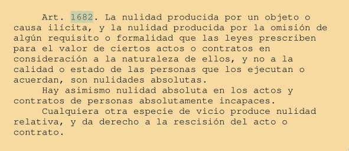

- efectos:
  1. sólo se producen una vez declarada por sentencia judicial ejecutoriada
  2. volver a las partes al estado que tenían antes de la celebración del acto nulo
  3. realizar las restituciones recíprocas
  - respecto a terceros

    declarada judicialmente da acción reivindicatoria frente a terceros Excepciones: - (A) No da acción reivindicatoria respecto: 1. rescisión por lesión enorme 2. muerte presunta 3. donación entre vivos 4. tercero poseedor que adquiere por prescripción 5. acción de indignidad para suceder
- clases:
  - Nulidad Absoluta

    Es la sanción legal impuesta a la omisión de los requisitos exigidos en consideración a la naturaleza o especie del acto.

    Procede en los ss. casos:
    1. Falta requisito de existencia
    2. Objeto o causa ilícita
    3. Actos de los absolutamente incapaces
    4. Error esencial
    - titulares
      1. juez, aparezca de manifiesto
      2. todo aquél que tenga interés pecuniario en ello
      3. por el ministerio público en interés de la moral y la ley
  - Características
    1. puede y debe ser declarada de oficio por el juez
    2. puede alegarla todo el que tenga interés
    3. puede solicitarla el ministerio público
    4. no puede ratificarse
    5. es irrenunciable / Es de orden público
    6. no se produce de pleno derecho (al igual que la relativa)
  - Nulidad Relativa

    Es la sanción por la omisión de algún requisito o formalidad que la ley exige en atención al estado o calidad de las partes. Está establecida para proteger los intereses de ciertas y determinadas personas, por lo que, no protege intereses generales. Procede:
  1. respecto de los acto de los relativamente incapaces cuando se omiten las formalidades habilitantes.
  2. respecto del dolo principal y determinante
  3. Error substancial
  4. Fuerza moral
  5. Error accidental
  6. Error en la persona
  7. Omisión de un requisito establecido para la validez del acto
  8. En los casos en que se establece como sanción respecto a la lesión
  - Titulares
    1. personas en cuyo beneficio se ha establecido la norma
    2. herederos
    3. cesionarios
  - Características
    - puede sanearse
      - por el trascurso del plazo para pedir rescisión = 4 años
      - por la voluntad de las partes = ratificación o confirmación (salvo declaración judicial)
    - da lugar la acción reivindicatoria
    - procedimiento: juicio ordinario
- Defina ineficacia en el sentido estricto

  La causa de ineficacia se origina después de haberse otorgado o celebrado el acto. Es decir, el acto jurídico por sí idóneo, no genera sus efectos o deja de producirlos, por un hecho **extrínseco**, una circunstancia usualmente sobreviniente o coetáneas y extrañas a su estructura.
  - Señale los casos de ineficacia en sentido estricto:
    - La suspensión

      Los efectos de un acto están subordinados a la ocurrencia de un hecho. Puede ser producto de la voluntad de las partes, como en el caso de la condición suspensiva o del plazo suspensivo o, puede ser producto de la ley en el caso de una condición legal como es el caso de las disposiciones testamentarias.
    - La resolución

      Los efectos de un acto pueden cesar y eliminarse la eficacia de los ya producidos, si sobreviene un hecho determinado, es un ejemplo la CRT.
    - La revocación

      Consiste en una declaración unilateral de voluntad por la retractación de un acto, incluso bilateral cuando la ley así lo autoriza. Es ejemplo del primero el caso del testamento. Es ejemplo del segundo el caso del mandato.
    - El desistimiento unilateral

      Una de las partes decide y comunica a la otra el término de una relación contractual, solamente cuando la ley lo autoriza, como por ejemplo el caso del desahucio en el contrato de arrendamiento.
    - La caducidad

      Puede entenderse como la pérdida de un derecho por no hacerlo valer en el plazo legal o contractual. Como ineficacia opera por el solo ministerio de la ley en algunos casos como por ejemplo: en el testamento privilegiado, en las donaciones revocables (por mortis causa) las cuales caducan por la muerte del donatario antes del donante
    - La resciliación

      Convención en virtud de la cual las partes de común acuerdo estipulan dejar sin efecto un contrato válidamente celebrado en la medida que sus efectos no estén totalmente cumplidos
    - La inoponibilidad

      Consiste en la ineficacia de un acto jurídico o la ineficacia de su nulidad, respecto de ciertos terceros, por no haber cumplido las partes algún requisito externo o por lesionar intereses ajenos.

## 2.7. Teoría de la Prueba Civil

- Qué se puede entender por prueba?
  1. Como **demostración** de la verdad de un hecho, de su existencia o inexistencia
  2. Como **medio de prueba**, medios de convicción.
  3. Como el hecho mismo de su producción, de hacerla valer ante TRB.
- Por qué se dice que la prueba también es materia propia del Derecho Civil?

  El CPC contiene normas de la manera como se rinden las pruebas en un juicio o un acto judicial no contencioso, pero la materia sobre la prueba es también sustancial:
  1. porque existen situaciones que deben probarse fuera de juicio, como sería la edad mínima para celebrar el contrato de matrimonio.
  2. porque presenta una parte sustantiva, a) determina los medios de prueba, b) señala su admisibilidad, c) determina el valor probatorio
- Cual es el objeto de la prueba?

  Son los *hechos*, el derecho conforme al art. 8 CC no necesita probarse.
  - Señale las excepciones
    1. Cuando la norma de derecho emana de la costumbre. (es excepción porque se debe probar derecho)
    2. Los hechos pacíficos (no controvertidos) no requieren prueba. (es excepción porque no se debe probar un hecho)
    3. Los hechos notorios no requieren prueba (es excepción por lo mismo de lo anterior)
- Qué es el onus probandi?

  Es una carga, una subordinación de los intereses del titular de ellos a otro interés de el mismo. Es decir, no está obligado a probar, pero si no se prueba, sus pretensiones no serán acogidas por el juez.
  - A quién incumbe probar?

    art. 1698 “incumbe probar las obligaciones o su extinción al que alega aquellas o ésta”. Es decir, como principio general corresponde probar al que ha sostenido una proposición contraria al estado normal u ordinario de las cosas, o al que pretende destruir una situación adquirida.
- Clasifique los hechos jurídicos para efectos probatorios

  Estas normas se aplican también respecto de los elementos del acto jurídico.
  - Hechos constitutivos

    Son aquellos que producen el nacimiento de un derecho o de una situación jurídica antes inexistente. Los genéricos (la capacidad, objeto, causa) no deben probarse. Los específicos si deben probarse. Por ejemplo en una CV se deberá probar que se acordó dar tal cosa y la otra pagar tal precio
  - Hechos impeditivos

    Aquellos que impiden la generación válida de una relación jurídica. Deben probarse, como por ejemplo los vicios del consentimiento
  - Hechos modificativos

    Son aquellos que alteran en su contenido o efectos la relación jurídica, deben probarse. Como por ejemplo las modalidades
  - Hechos extintivos

    Son aquellos que hacen desaparecer una relación jurídica o sus efectos, deben probarse. Como lo son los modos de extinguir las obligaciones.
- Quién puede cambiar el peso de la prueba?

  La ley, estableciendo presunciones legales y la voluntad de las personas, a través de las convenciones entre las partes. Es decir, las normas del onus probandi son de orden privado y renunciables por las partes.
- Cómo opera la prueba de los hechos negativos?

  Pueden y deben probarse, dado que toda proposición negativa implica una proposición positiva o afirmativa que es su antítesis. Si se sostiene que no estaba en X lugar, puede probar que estaba en el lugar Y.

# 3. Sujetos de Derecho

- Como se clasifican las personas?
  - Personas naturales

    art. 55 Son personas todos los individuos de la especie humana, cualquiera sea su edad, sexo, estirpe o condición
    - Requisitos para que el nacimiento constituya principio de existencia legal de la persona:
      1. Que sea separado completamente de la madre
      2. Debe haber sobrevivido a la separación un momento siquiera
    - Qué es y hasta cuando dura la existencia natural de la persona?

      Se dice existencia natural la que principia en la concepción y termina en el nacimiento. el CC señala en el art. 75 “la ley protege la vida del que está por nacer”
    - Presunción de concepción

      art. 76 se presume de derecho que la época de concepción ha precedido al nacimiento en no menos de 180 días y no más de 300, contados hacia atrás, **desde la medianoche en que principie el día del nacimiento**.
    - Qué efectos produce el nacimiento de una persona?
      1. Se termina la existencia natural y se **da comienzo a la existencia legal**
      2. Nacen los **atributos de la personalidad**
      3. art. 77 los derechos patrimoniales que se encontraban en suspenso *se radican en el patrimonio* del recién nacido. Por lo que, si fallece, los transmitirá a sus herederos.
    - Hasta cuándo dura la existencia legal de la persona?

      art. 78 La persona (se refiere a la existencia legla) termina en la muerte natural. Consiste en la cesación de los fenómenos de la vida, de las funciones respiratorias y encefálicas.
    - Como se clasifica la muerte?
      - Muerte real

        Es aquella que efectivamente consta que la persona murió y se certifica el cese de sus funciones vitales por un medico.
        - Qué efectos produce la muerte real de la persona?
          1. Da origen al modo de adquisición del dominio que es la sucesión por causa de muerte
          2. Pone fin a la personalidad del individuo (existencia legal)
          3. Pone fin al matrimonio
          4. Pone fin a la patria potestad
          5. Da fuerza legal al testamento
          6. Pone fin a ciertos contratos (intuito personae, o que tengan una preponderancia especial la consideración de la persona con la cual se contrata)
          7. Algunas instituciones terminan por la muerte de quien la desempeña (las guardas)
          8. Se extinguen determinadas acciones civiles como la acción de nulidad del matrimonio, salvo excepciones.
          9. Se extinguen los derechos intransmisibles como lo son el derecho a pedir alimentos, el usufructo, el uso o habitación.
      - Muerte presunta

        art. 81 se presume muerto al individuo que ha desaparecido, ignorándose si vive y verificándose las condiciónes que se señalan.
        - Cuales son los elementos tomados en cuenta para presumir que la persona ha muerto?
          1. la ausencia o desaparecimiento
          2. la carencia de noticias sobre éste
        - Qué toma en consideración la ley para que exista esta institución?
          1. Toma en consideración el interés de la persona desaparecida
          2. El interés de los terceros, respecto a eventuales derechos de sucesión
          3. El interés general de la sociedad en que no existan bienes o derechos abandonados
        - Cuales son los requisitos para que proceda la declaración de muerte presunta?
          1. Que sea declarada por sentencia judicial
          2. Que se haga conforme a las disposiciones procesales del CPC
          3. Que el indivíduo haya desaparecido
          4. Que no se tenga noticia de su existencia
        - Periodos o etapas de la muerte presunta
          1. mera ausencia
          2. posesión provisoria
          3. posesión definitiva
        - Quiénes pueden pedir la declaración de muerte presunta?

          Cualquiera que tenga interés (*pecuniario*) en su declaración. Los acreedores pueden dirigirse al apoderado del ausente o provocar el nombramiento de un curador.
        - Quién es competente para declarar la muerte presunta de una persona?

          art. 81 CC y 151 COT el juez del último domicilio que el desaparecido haya tenido en Chile.
        - Formalidades para la solicitud de declaración de muerte presunta
          1. los interesados deben justificar que **se ignora** el paradero del desaparecido y que se han hecho las posibles diligencias para encontrarlo
          2. **citación** del desaparecido, por 3 veces con diferencia de 2 meses entre cada una en el periódico oficial
          3. intervención del **defensor de ausente** (defensor público)
          4. todas las sentencias (interlocutorias y definitivas) deben ser **insertadas en periódico oficial**
          5. fijación del **día presuntivo** de la muerte (r. g. el último día del primer bienio)
        - Qué es el periodo de mera ausencia?

          Es el que dura desde la fecha de las últimas noticias respecto del desaparecido hasta el decreto de posesión provisoria o definitiva, o por la reaparición del desaparecido o con la confirmación de su muerte.
          - Qué ocurre con la administración de los bienes?
            1. Si el desaparecido tiene representante legal le corresponderá a el
            2. Si dejo mandatario, le corresponderá a el
            3. Si no dejó mandatario y no tiene representante legal, se nombrará curador de ausentes (su nombramiento puede ser provocado por cualquiera que tenga interés patrimonial en ello)
    - Término del periodo de mera ausencia:
      - Decreto de posesión provisoria
      - Decreto de posesión definitiva
      - Reaparecimiento del ausente
      - Conocimiento positivo de la fecha de muerte real del desaparecido.
  - Qué es la posesión provisoria?

    Es aquella que empieza con la resolución que la declara y termina con la resolución judicial que concede la posesión definitiva.
    - la cual, produce los siguientes *efectos*
      1. disuelve la sociedad conyugal
      2. se procederá a la apertura y publicación del testamento
      3. emancipación legal de los hijos, salvo que correspondiera al otro cónyuge
      4. la posesión provisoria sobre los bienes del desaparecido a los herederos presuntivos
  - Qué es la posesión definitiva?

    Es la resolución judicial que se declara cuando termina la posesión provisoria, produciendo los siguientes efectos:
    1. pone fin a la posesión provisoria
    2. disuelve el matrimonio
    3. terminan las cauciones otorgadas para disponer de los bienes que se poseían provisoriamente
    4. se terminan las limitaciones para disponer de los bienes del desaparecido que tenían los herederos presuntivos
    5. se pueden hacer valer los derechos sujetos a la muerte del desaparecido, como en el caso del usufructo
    6. los legatarios pueden exigir sus derechos.
       - Cuando se decreta la posesión definitiva?
         1. cuando cumplido los 5 años (de la última noticia), se probare que el desaparecido tiene más de 70 años.
         2. Inmediatamente con el transcurso de los 5 años desde la fecha de la herida grave en la guerra o peligro similar
         3. Inmediatamente transcurrido 3 meses desde la fecha de la última noticia que se tuvieron de la nave o aeronave reputada perdida
         4. Inmediatamente luego de 6 meses desde sismo o catástrofe
         5. en último caso, transcurrido 10 años desde la última noticia
       - Qué obligaciones protegen los bienes del desaparecido?
         1. inventario solemne
         2. caución de conservación y restitución
       - Cuando autoriza la ley a pedir rescisión del decreto judicial de muerte presunta?
         1. si se tuvieren noticias de la existencia del desaparecido
         2. si hubiere noticias de la muerte real del desaparecido
         3. si reaparece.
       - a favor de quiénes se puede rescindir?
         1. del desaparecido que reaparece
         2. los legitimarios habidos durante el desaparecimiento
         3. cónyuge
- Son atributos de la personalidad:
  - 1. **la nacionalidad**

       Consiste en el vínculo de derechos y obligaciones que une a individuo con el Estado por el hecho de haber adquirido la nacionalidad por alguna de las causales que establece la CPR

    art. 56 señala que son chilenos los que la CPR declara como tales, la CPR art. 10 señala que son chilenos:
    1. Los nacidos en territorio de Chile
    2. Los hijos de padre o madre chilenos, nacidos en territorio extranjero
    3. Los extranjeros que obtuvieren carta de nacionalización en conformidad a la ley
    4. Los que obtuvieren especial gracia de nacionalización por ley - Como se pierde la nacionalidad (art. 11 CPR)? 1. Por **renuncia voluntaria** si la persona se ha nacionalizado en país extranjero 2. Por **Decreto Supremo** en caso de prestación de servicios durante una guerra exterior a enemigos de Chile 3. Por **ley** que revoque la nacionalización concedida por gracia
  - 2. **el nombre**

       Conjunto de palabras que sirven para distinguir legalmente a una persona de otra.

       Ley 4.808 art. 30 La inscripción del nombre puede ser requerida por padre o madre por sí o por mandatario dentro de los 30 días siguientes al nacimiento de la criatura.

       art. 28, 29 se deberá hacer por las personas indicadas (padre, pariente más cercano mayor, medico que hubiera ocurrido al nacimiento, jefe del establecimiento) dentro de los 60 días.

       Se puede colocar cualquier nombre, salvo que sea extravagante, ridículo, impropio de persona, equívoco respecto a su sexo o contrario al buen lenguaje
  - 3. **el estado civil**

       Consiste en la calidad que tiene una persona en cuanto lo habilita para ejercer ciertos derechos y contraer ciertas obligaciones civiles
       - características
         1. es un atributo de la personalidad
         2. su regulación es de orden público
         3. es un derecho extra patrimonial (no se traspasa)
         4. es permanente, mientras no se adquiere otro
         5. es uno e indivisible, sin perjuicio de que se puede tener más de uno con relación a fuentes distintas, como pueden concurrir el de hijo, soltero y padre
         6. es imprescriptible
         7. es irrenunciable
            - Cuales son los principales *efectos* del estado civil?
              1. da origen a derechos y obligaciones
              2. da origen al parentesco
                 - Clasificación
                   - Natural o de consanguinidad

                     Es la relación de sangre entre dos personas que descienden unas de las otras o de un tronco común
                   - Legal o por afinidad

                     Es el que existe entre una persona que está o ha estado casada y los consanguíneos de su marido o mujer
                   - Adopción

                     Conforme a la Ley 19.620
                 - Como se estructura el parentesco?
                   - línea de parentesco

                     Consiste en el número de generaciones que existe entre dos personas
                   - línea colateral

                     Es aquella que se forma con el vínculo a un tronco común
                   - el grado

                     Es el número de generaciones que separan a los parientes
            - como se prueba el estado civil?

              A través de los certificados o partidas que emite el Registro Civil, los cuales constituyen instrumentos públicos.

              A falta de dichos instrumentos públicos, se puede probar por:
              1. Otros documentos auténticos (como seria un testamento en que se reconoce un hijo)
              2. Declaraciones de testigos presenciales al hecho (como lo sería la declaración del medico que constata la muerte de una persona)
              3. Por la posesión notoria del estado civil, en el caso del matrimonio, siempre que sea de nombre, trato y fama, a lo menos por 10 años de forma pública y continua.
            - cuales son las fuentes del estado civil?

              Por su carácter de orden público se encuentra excluido del ámbito de la autonomía de la voluntad
              1. La ley
              2. Hechos naturales
              3. Sentencia Judicial
         - el domicilio

           Consiste en la residencia acompañada real o presuntiva de la intención de permanecer en ella. Se diferencia con:
           - habitación

             asiento ocasional esencialmente transitorio
           - morada

             casa que se habita para tener en ella hogar o asiento de negocios
           - residencia

             lugar que se tiene para estar con cierta permanencia. art. 68 señala que hace las veces de domicilio respecto de aquellos que no lo tuvieran en otra parte
           - Qué importancia tiene el domicio?
             1. respecto del pago de la obligación, la regla general es que sea en el domicilio del deudor
             2. en materia sucesoria, la sucesión se abre en el último domicilio del causante
             3. en materia judicial, determina la competencia del TRB
             4. la declaración de muerte presunta se debe pedir en el último domicilio que tuvo el desaparecido
         - la capacidad de goce

           La capacidad de goce consiste en la aptitud de las personas en ser titular de derechos, consiste en un atributo de la personalidad el cual nace con la persona. No existe incapacidad de goce general, sino que solamente respecto a determinados derechos.
           - qué es la capacidad legal?

             Se refiere a la capacidad de ejercicio, la cual se entiende como la que tiene una persona para obligarse a sí misma, sin el ministerio o la autorización de otra
         - Por lo que, se clasifica de la siguiente manera:
           1. capacidad de goce = aptitud para *adquirir*
           2. capacidad de ejercicio = aptitud para ejercer derechos y cumplir por sí mismo, sin el ministerio o autorización de otra
         - el patrimonio

           Es una universalidad de bienes y deudas apreciables en dinero que constituye un atributo de la personalidad
           - características
             1. se deduce de la idea de personalidad
             2. todas las personas lo tienen por ser tal
             3. aun cuando no se posea nada, es una aptitud para poseer
             4. abstracta, independiente de la existencia de bienes o deudas
             5. es incomerciable
             6. inalienable
             7. imprescriptible
             8. inembargable, sin perjuicio de los bienes que lo integran
    - Personas jurídicas

      art. 545 se llama persona jurídica una persona ficticia, capaz de ejercer derechos y contraer obligaciones civiles y de ser representada judicial y extrajudicialmente
      - Requisitos de existencia
        1. Debe ser una entidad distinta e independiente
        2. Que sea reconocida por el Estado derechos y obligaciones
      - Clasificación
        1. De derecho privado = **con fines** de lucro (Soc. Industriales = civiles, comerciales); **sin fines** de lucro (Corporaciones, Fundaciones)
        2. De derecho público = son aquellas que representan a la autoridad en sus funciones administrativas como las municipalidades, el fisco.
        - diferencias
          1. respecto a la iniciativa = resolución de una autoridad, iniciativa de particulares
          2. respecto a las potestades públicas = imperio (dictar normas con carácter obligatorio), solo obligatoria para sus socios
          3. respecto a su fin = fines públicos, fines particulares
          4. respecto a sus recursos = recursos públicos, de sus propios asociados
      - Corporaciones o Asociaciones

        Son colectividades de personas asociadas para conseguir un fin no lucrativo y común de ayuda a sus miembros, con medios propios y dotadas de personalidad jurídica
        - Constitución
          1. Constará en escritura pública o privada, individualizando quienes comparecen otorgándolo, expresando la voluntad de constituir una persona jurídica
          2. Depositar copia autorizada en Secretaría Municipal dentro de los 30 días
          3. 30 días para que Secretario Municipal objete fundadamente la constitución
          4. 30 días para subsanar las observaciones formuladas contados desde la notificación de la objeción
          5. transcurrido el plazo para objetar y dentro del 5to día archivará copia y remitirá al SRCI para su inscripción en el Registro Nacional de Personas Jurídicas sin Fines de Lucro, la cual gozará de personalidad jurídicas a partir de ese día.
        - Estatuto
          1. nombre y domicilio de la p. jurídica
          2. duración
          3. fines a que está destinada
          4. bienes que forman su patrimonio y forma de aporte
          5. órganos de administración, integración y atribuciones
          6. reforma de estatutos, extinción de la p. jurídica, indicando a cual institución sin fines de lucro pasará los bienes
        - Administración

          recae en un directorio de al menos tres miembros, cuyo mandato podrá extenderse hasta por 5 años, su presidente será también el presidente de la asociación
        - Fiscalización

          Corresponde al Ministerio de Justicia, pudiendo requerir sus actas de las asambleas y de las sesiones de los directorios, las cuentas y memorias aprobadas, libros de contabilidad, de inventarios y de remuneraciones, como cualquier otra información respecto al desarrollo de sus actividades. El cual, podrá solicitar que se subsanen las irregularidades o que se persigan las responsabilidades pertinentes. El incumplimiento de las instrucciones impartidas por el Ministerio de Justicia se mirará como infracción grave a los estatutos.
        - Disolución
          1. vencimiento del plazo
          2. acuerdo de la asamblea general extraordinaria
          3. sentencia judicial ejecutoriada (esta prohibida por la CPR o la ley, infringe gravemente sus estatutos), haberse realizado íntegramente su fin o hacerse imposible su realización
          4. demás causas previstas en los estatutos o leyes
      - Fundaciones

        son establecimientos y obras creadas por una persona habiéndoselos dotado de un patrimonio a tal objeto destinado, y conformándose en su acción a un estatuto establecido en el acta de constitución
        - constitución
          1. acto entre vivos = fundador establecerá quién se queda con su dinero y con cuales obligaciones
          2. por acto testamentario
        - extinción
          1. cancelación de la personalidad jurídica
          2. orden del Presidente de la República, cuando hayan perecido los bienes destinados a su mantención
          3. disuelta la fundación los bienes serán destinados al objetivo establecido en los estatutos, si no dijeran nada, el Presidente de la República los dispondrá
      - diferencias entre fundación y corporación
        1. respecto al circulo o núcleo de interesados, la fundación carece de uno
        2. respecto a su patrimonio, en la corporación éste se va suministrando por sus miembros a diferencia de la fundación que está dado por su fundador y dirigido al fin de la misma.
        3. respecto a la voluntad de la persona jurídica, en la fundación está determinada para siempre por la voluntad de su fundador, a diferencia de la corporación que la constituye la voluntad de sus miembros
      - Responsabilidad
        - responsabilidad penal de la persona jurídica

          Ley 20.393 sólo respecto a determinados delitos como el de lavado de activos, financiamiento del terrorismo, cohecho de funcionario público. Afecta a las personas jurídicas de derecho privado con o sin fines de lucro y a empresas del Eº.

          se configura cuando una de las personas naturales con facultad de dirección en la empresa, algún subordinado de ella o algún funcionario que tenga facultades de administración y supervisión, cometa alguno de los delitos mencionados en interés o provecho directo de la empresa, y que ésta no haya adoptado o implementado modelos de organización, administración y supervisión para prevenir estos delitos o habiéndolos implementado, estos hayan sido insuficientes.

          penas:
          1. disolución de la p. jurídica o cancelación de la p. jurídica
          2. prohibición temporal o perpetua de celebrar actos y contratos con los organismos del Eº
          3. perdida total o parcial de beneficios fiscales o prohibición absoluta de recepción de los mismos por un período determinado
          4. multa a beneficio fiscal de 200 a 20.000 UTM
        - responsabilidad civil
          - 1. contractual

            Además de los requisitos comunes para que el juez acceda a la indemnización de perjuicios, se dice que se requiere:
            1. que se contraiga obligación a nombre de la persona jurídica
            2. que se tenga personería suficiente, que no excedan los límites de su mandato
          - 2. extracontractual

            art. 2320 tenga o no representación. Señala el articulo que “toda persona es responsable no sólo de sus propias acciones, *sino (también) del hecho de aquellos que estuvieren a su cuidado*”. Luego, lo ejemplifica el inc. 4º, “empresarios del hecho de sus aprendices o dependientes”.

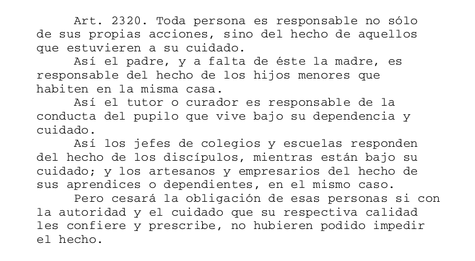

            - ocasionados por delito o cuasidelito penales y civiles

              art. 58 inc. 2º CPP relacionado con el art. 2314. Por las personas jurídicas responden los que hubieren intervenido en el acto punible, sin perjuicio de la responsabilidad civil que las afecte.

              art. 2314 El que ha cometido un delito o cuasidelito que ha inferido daño a otro, es obligado a la indemnización; sin perjuicio de la pena que le impongan las leyes por el delito o cuasidelito.
            - ocasionado por delito o cuasidelitos exclusivamente civiles

              Se aplica el art. 2314 El que ha cometido un delito o cuasidelito que ha inferido daño a otro, es obligado a la indemnización; sin perjuicio de la pena que le impongan las leyes por el delito o cuasidelito.

# 4. Objeto del Derecho

- Bienes

  Son los que, pudiendo procurar al hombre una utilidad, es susceptible de apropiación por los particulares
  - Clasificación
    - Corporales

      Son los que tienen existencia real y pueden ser percibidos por los sentidos.
      - muebles

        Por naturaleza = que pueden transportarse de un lugar a otro, sea por una fuera externa o por sí mismos

        por anticipación = los que unidos a un inmuebles se consideran muebles para efectos de constituir derechos sobre ellos
      - inmuebles

        por naturaleza = no pueden transportarse de un lugar a otro

        por adherencia = m. por naturaleza, se reputan inmuebles por estar **permanentemente adheridos**

        por destinación = m. por naturaleza, **permanentemente destinados al uso, cultivo o beneficio** de un inmueble
    - Incorporales

      Consisten en meros derechos
      - Derechos reales

        sobre una cosa sin respecto a determinada persona, acciones reales
      - Derechos personales

        solo pueden reclamarse de ciertas personas que por un **hecho suyo** o la **sola disposición de la ley** han contraído las obligaciones correlativas, acciones personales
    - Divisibles e Indivisibles

      atendiendo a si su división afecta su utilidad
    - Consumibles e Inconsumibles

      conforme a si perecen o no con su primer uso al menos para su dueño
    - Fungibles y no fungibles

      conforme a si tienen o no el mismo poder liberatorio
    - De consumo y de medios de producción

      si satisfacen directa e inmediatamente las necesidades de las personas o si tiene por finalidad la producción de otros bienes
    - Principales y Accesorios

      si tienen una existencia por sí mismos o si necesariamente requieren la existencia de otro
    - Singulares y Universales

      Conforme a si constituyen una unidad ya sea natural o artificial. Son universales aquellas que a pesar de conservar su individualidad, forman un todo al estar unidas por un vínculo de igual destino, recibiendo una denominación común
    - Otros

      Bienes presentes y futuros

      comerciables e incomerciables

      apropiables e inapropiables

      privados y públicos
- El dominio

  art. 582 es el derecho real en una cosa corporal, para gozar y disponer de ella arbitrariamente, no siendo contra ley o contra derecho ajeno. Sobre las cosas incorporales hay también una especie de propiedad.
  - características
    1. derecho real, amparado por la acción reivindicatoria
    2. absoluto, las más amplias facultades (usar, gozar y disponer)
    3. exclusivo y excluyente, impide que terceros limiten o coarten el ejercicio de sus facultades
    4. perpetuo
  - limitaciones
    1. ley
    2. derecho ajeno
    3. expropiación por utilidad pública
    4. ordenanzas municipales
    5. servidumbres prediales
    6. servicios eléctricos
    7. sentencia judicial
    8. teoría del abuso del derecho
  - clasificación
    - Plena y nuda

      Es nuda cuando el dueño se desprende del uso o goce, conservando la facultad de disposición
    - Absoluta o fiduciaria

      Es fiduciaria la que se encuentra sujeta a gravamen de pasar a otra persona por el hecho de la verificación de una condición
    - Individual o copropiedad

      Es copropiedad aquella en que varias personas son titulares del derecho de dominio sobre una misma cosa
    - Civil, minera, industrial, indígena

      conforme a que leyes se rige
- Modos de Adquirir
  - Concepto
    1. Modo de Adquirir = hechos materiales que la ley le atribuye la virtud de hacer nacer o traspasar el derecho de dominio
    2. Título = hecho o acto jurídico que habilita y sirve de justificación para la adquisición del dominio o derecho real respectivo.
  - clasificación
    - originarios y derivativos

      conforme a si existe o no una relación de causa y efecto entre el antecesor, nadie puede transferir más derechos de los que tiene.

      son originarios: ocupación, accesión y la prescripción

      son derivativos: tradición, SPCM
    - a titulo singular y a titulo universal

      ocupación y accesión

      SPCM
    - entre vivos o por causa de muerte

      por mortis causa la SPCM
    - a titulo gratuito y a titulo oneroso

      la tradición puede ser a titulo oneroso como también a titulo gratuito
  - la ocupación

    es el modo de adquirir las cosas **que no pertenecen a nadie** y cuya adquisición **no está prohibida por las leyes chilenas o el Derecho Internacional**, mediante la **aprehensión material** de ellas, **con la intención de adquirirlas**
  - la accesión

    es un modo de adquirir por el cual el dueño de una cosa pasa a serlo de lo que ella produce o de lo que se junta a ella
    - clasificación
      - accesión de frutos
        - frutos

          toda emanación periódica de una cosa sin detrimento de la cosa productora. 1) periodicidad, 2) sin detrimento, 3) conforme a su estimación natural o económica.

          civiles = utilidades pecuniarias, terceros al dueño, virtud de contrato, por el uso y goce

          naturales = ya sea con o sin la ayuda industrial del hombre
        - productos

          todo lo que se obtiene de la cosa aun cuando para obtenerlo produzca su detrimento, como sería la tala de un bosque para vender sus maderas.
      - accesión propiamente tal
        - Inmueble a inmueble
          1. aluvión = aumento que recibe la ribera de la mar, rio o lago por el lento, imperceptible y definitivo retiro de las aguas
          2. avulsión = aquella parte del suelo que arrancada por una avenida u fuerza natural violenta, es transportada por el agua a un predio inferior
          3. cambio de cause del rio
          4. formación de una nueva isla
        - mueble a inmueble

          edificación y plantación o siembra ejecutados en un inmueble, cuando los materiales, plantas o semillas pertenecen distintas que el dueño del suelo
        - mueble a mueble

          adjunción = dos cosas pertenecientes a distintos dueños se junta a otra, pero de modo que pueden separarse y subsistir cada una después de separada, como un espejo que se pone en un marco ajeno.

          especificación = cuando de la materia perteneciente a una persona, hace otra persona una obra o artefacto cualquiera

          mezcla = cuando se juntan materias solidas o líquidas pertenecientes a diferentes dueños, de manera que es imposible separarlos.
  - la tradición

    es un modo de adquirir el dominio de las cosas y consiste en la entrega que el dueño hace de ellas a otro, habiendo por una parte la facultad e intención de transferir el dominio y por la otra la capacidad e intención de adquirirlo, lo que se dice respecto al dominio también se extiende a los otros derechos reales.
    - Requisitos de la tradición
      - Capacidad del tradente y del adquirente
      - Consentimiento
      - TTD
      - Entrega material
    - Tiene las ss. características:
      - es un MAD derivativo
      - puede ser a título oneroso como gratuito
      - por RG es a título singular, pero puede ser a título universal también
      - opera entre vivos
      - es una convención que extingue obligaciones
      - es un MAD y demás derechos reales
      - sobre bienes corporales como incorporales
    - época de pedir la tradición

      RG inmediatamente, excepción:
      1. titulo condicional
      2. existencia de plazo para el pago
      3. cuando ha intervenido decreto judicial en contrario
    - Diferencia entre entrega y tradición:
      - la entrega se refiere a la entrega **material** de una cosa a manos de otra persona
      - la tradición implica la entrega (como elemento material), *más* un elemento intencional, el cual, es el **título traslaticio de dominio**
    - título

      es el hecho o acto jurídico que sirve de antecedente para la adquisición. De el solo nacen derechos personales para exigir la transferencia del dominio.
    - función de la inscripción en el registro del CBR
      1. tradición, como MAD = única forma de realizar la tradición de inmuebles y de los derechos reales constituidos en ellos, con excepción del dº real de herencia y servidumbres
      2. como formalidad de publicidad = ejemp. sentencia que declara la prescripción adquisitiva, renuncia de un dº real, resolución de interdicción provisoria o definitiva, resolución que confiere el beneficio de separación, gravamen sobre un inmueble, prohibición embargo o retención judicial legal o convencional
      3. requisito de garantía y prueba de la posesión de los bienes inmuebles = la posesión cesa por la cancelación de la inscripción (voluntad de las partes, nueva inscripción, decreto judicial)
      4. mantener la historia de la propiedad raíz
      5. solemnidad = casos de donaciones entre vivos, fideicomisos sobre inmuebles, usufructos sobre inmuebles, para la validez de censo e hipoteca, constitución de uso o habitación.
    - títulos que se **deben** inscribir
      1. títulos traslaticios de dominio de los bienes inmuebles
      2. la constitución de los fideicomisos que comprendan o afecten bienes
      3. renuncia de alguno de los anteriores
      4. decretos de interdicción provisoria y definitiva, de rehabilitación del disipador y demente
    - títulos que **pueden** inscribirse
      1. toda condición suspensiva o resolutoria del dominio de bienes inmuebles o de otros dº reales constituidos sobre ellos
      2. todo gravamen impuesto que no sea los 2 números anteriores, como servidumbres y arrendamiento u otro que sea permitida su inscripción
      3. todo impedimento o prohibición referente a un inmueble, sea convencional, legal o judicial como el embargo.
    - Tradición de los derechos personales:

      En general, se realizan por la entrega del título del cedente al cesionario. La cual puede ser de tres tipos:
      - en nominativo: aceptado o notificado al deudor. Se encuentra regulado en el CC
      - a la orden: efectuándose mediante el endoso. CdeCom.
      - al portador: por la entrega del título. CdeCom.
    - La posesión

      es la tenencia de una cosa determinada con ánimo de señor y dueño, sea que el dueño o quien se da por tal tenga la cosa por sí misma, o por otra persona que la tenga en lugar y a nombre de él. El poseedor es reputado dueño mientras otra persona no justifica serlo.
      - Elementos:
        - tenencia
        - cosa determinada
        - ánimo de señor o dueño
      - Importancia:
        - se presume dueño
        - acción publiciana (buena fe)
        - sobre inmueble = acción posesoria
        - prescripción adquisitiva
        - buena fe = hace suyos los frutos
      - Diferencias con el dominio:
        - posesión = hecho; dominio = derecho
        - posesión = acciones de corto tiempo; dominio = reivindicatoria mientras otro no adquiera la cosa por adquisitiva
        - posesión = puede poseerse por varios títulos; dominio = solo puede adquirirse por 1 modo.
      - clasificación
        - posesión regular / irregular

          la irregular carece de uno de los requisitos de la regular (los cuales son: a) justo título, b) buena fe inicial, c) tradición si es TTD)
          - 1. títulos injustos (“no es justo título”, art. 704)
            1. el falsificado
            2. el conferido por persona en calidad de mandatario o representante legal sin serlo
            3. el que adolece de vicio de nulidad
            4. el meramente putativo
          - 2. buena fe

            conciencia de haberse adquirido el dominio de la cosa por medios legítimos, exentos de fraude o de todo otro vicio, la cual, por r.g. se presume
            - se presume la mala fe
              1. error de derecho (posesión)
              2. título de mera tenencia
              3. cuando se ha ocultado la verdadera muerte o existencia respecto de la posesión de los bienes del desaparecido
              4. al contestar la demanda
          - 3. TTD

            Cuando se trate de la tradición, se exige que exista un título traslaticio de dominio, el cual consta la voluntad de las partes.
        - posesión viciosa / útil

          es viciosa la violenta o clandestina y no permiten prescribir
        - posesión continua / interrumpida

          es continua la que no ha sido perdida, impedida o desconocida
      - adquisición, conservación y perdida
        - muebles

          adquisición = corpus y animus (capaces)

          conservación = basta el animus

          perdida = se puede perder por falta de uno u otro (*corpus* = otro se apodera con animo de hacerla suya, imposible su ejercicio, se arrojan al mar, se pierden materialmente y no están bajo poder), (*animus* = constituto posesorio), (*corpus y animus* = cuando se enajena la cosa por tradición o se abandona para que la haga suya el primer ocupante)
        - inmuebles no inscritos

          art. 729, al igual que los bienes muebles, sin perjuicio que dicho art. señala que si alguien pretendiéndose dueño se apodera violenta o clandestinamente de un inmueble cuyo título no está inscrito, el que tenía la posesión la pierde.

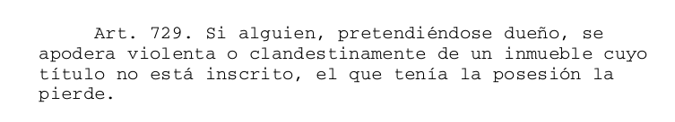

        - inmuebles inscritos
          - adquisición
            1. por título constitutivo
            2. por título traslaticio
          - conservación

            se conserva mientras la inscripción no se cancele
          - pérdida

            solamente por la **cancelación** de la inscripción, la que, puede ocurrir por:
            1. voluntad de las partes
            2. decreto judicial
            3. por nueva inscripción (si el título es justo o injusto, se cancela la anterior, si es mero tenedor el que enajena, la mayoría de la doctrina señala que cancela la anterior)
  - la prescripción (*adquisitiva*)

    MAD de las cosas ajenas por haberse poseído las cosas durante un cierto lapso de tiempo y concurriendo los demás requisitos legales.
    - Elementos:
      - posesión
      - títular inactivo
      - trascurso de un lapso de tiempo
    - reglas comunes a la prescripción
      1. debe ser alegada, salvo acción penal, pena, prescripción del título ejecutivo
      2. puede ser renunciada
      3. corre contra todo tipo de persona
      4. debe ser declarada por sentencia judicial
      5. se adquiere por todos los derechos, gravámenes y limitaciones
      6. opera retroactivamente.
    - Casos que no procede prescripción adquisitiva:
      - Servidumbres discontinuas o continuas inaparentes
      - Derechos personales
      - Cosas incomerciables
      - Los derechos que tienen los propietarios de servirse de las aguas de lluvia
    - Requisitos de procedencia prescripción adquisitiva
      - Cosa susceptible de adquisición por prescripción
      - Posesión útil y continua (la posesión útil puede ser regular o irregular)
      - Tiempo, regular = 2 años muebles y 5 inmuebles; irregular = 10 años
    - Clases de Prescripción Adquisitiva:
      - ordinaria
        - posesión regular
        - tiempo, 2 años muebles; 5 años inmuebles
        - se suspende
      - extraordinaria
        - posesión irregular
        - tiempo, 10 años
        - no se suspende
    - Efectos que produce la prescripción:
      - es un MAD
      - confiere acción y excepción
      - opera en forma retroactiva
- Acción reivindicatoria

  art. 889, o acción de dominio es la que tiene el dueño de una cosa singular, de que no está en posesión, para que el poseedor de ella sea condenado a restituírsela.
  - pretensión

    Que se le reconozca su dominio y que se ordene, por parte del juez, al que se encuentra poseyendo la cosa, que lo restituya en la posesión perdida.
  - procedimiento judicial
    1. juicio de lato conocimiento, procedimiento ordinario
    2. si es mueble, será competente el juez de letras del domicilio del demandado
    3. si es inmueble, será el juez de letras del lugar en que se encuentra el inmueble.
  - efectos

    **restituciones mutuas** = vencido restituir la cosa y los frutos, respondiendo de los deterioros y pérdidas, siendo obligado el vencedor en abonar las mejoras y gastos.
  - cosas que pueden ser reinvindicables

    RG todas las cosas, muebles e inmuebles, corporales e incorporales. Salvo:
    1. cosas compradas en feria, tienda, almacén u otro establecimiento industrial en que se vendan cosas muebles de la misma clase. Deberá reembolsar al poseedor lo que haya dado por ella y lo que haya gastado en repararla y mejorarla
    2. solamente cosas singulares y universalidades de hecho. No se pueden reivindicar las universalidades de derecho.
    3. la herencia se reivindica por una acción especial denominada “acción de petición de herencia”. Se diferencia con la reivindicatoria en que no puede accionar indistintamente, debe ser en contra del heredero putativo u otro título.
    - Reivindicación de una cuota determinada pro indiviso, de una cosa singular:
      - Cuota debe ser determinada
      - Cosa singular proindiviso
    - Titulares de la acción reivindicatoria:
      - propietario
      - comprador de una cosa a quien no se le ha hecho tradición no puede reivindicar
      - pleno o nudo propietario
      - absoluto o fiduciario
      - copropietario por su cuota
    - Contra quien se puede reivindicar?
      - actual poseedor
      - poseedor que haya dejado de serlo
        - 1. restitución de todo lo que haya recibido por ella = si se ha hecho imposible o difícil persecución
        - 2. indemnización de todo perjuicio = si se enajenó a sabiendas
      - El injusto detentador
  - acción publiciana

    Art. 894 se concede la misma acción (reivindicatoria) aun que no se pruebe el dominio, al que ha perdido la posesión regular de la cosa, y se hallaba en el caso de poderla ganar por prescripción, pero no contra el verdadero dueño ni contra quien lo posea con igual o mejor derecho.
    - prueba
      1. el poseedor se reputa dueño
      2. fisco se reputa dueño de aquellas tierras que carecen de uno
      3. que el dominio se adquirió por algún modo (ocupación, accesión, prescripción, tradición, remontándose hasta un MAD originario, 10 años)
      4. que el demandado se encuentra en posesión de la cosa
      5. determinación e identificación de la cosa
    - prestaciones mutuas

      terminado el juicio reivindicatorio, vencido el demandado, se da lugar a las prestaciones mutuas

      consiste en los hechos y pagos que el poseedor vencido debe hacer en favor del reivindicante y que éste a su vez debe hacer en favor del poseedor.

      estas reglas se aplican también la **nulidad, accesión de mueble a inmueble y ala acción de petición de herencia**.
      - prestaciones del poseedor vencido a favor del reivindicante
        - restitución de la cosa

          dentro del plazo que señale el juez, comprende la cosa misma, las cosas inmuebles por adherencia o destinación, cuestiones accesorias que hayan sido comprendidas en la demanda y sentencia y los títulos que conciernen a la cosa. Al momento de la entrega es conveniente que se haga ante un ministro de fe para que deje constancia del estado de la cosa.
        - indemnización deterioros

          no se es responsable de los deterioros que por su hecho o culpa sufra la cosa (a menos que se haya aprovechado de ellos, haciéndose más rico), mientras no conteste la demanda. Por lo que, se entiende en buena fe hasta el momento de la contestación.
        - restitución de frutos

          poseedor de mala fe debe restituir los frutos civiles y naturales que el dueño hubiera podido percibir con la mediana inteligencia y actividad. Pagando su valor en caso que no existan. Estos se restituyen líquidos, descontando los gastos ordinarios invertidos para producirlos
        - gastos del pleito, conservación y custodia

          si es condenado en costas. Poseedor de mala fe deberá pagar los gastos de conservación y custodia en caso de medida precautoria de secuestro.
      - Prestaciones del reivindicante en favor del poseedor vencido
        1. gastos **ordinarios de producción de los frutos**
        2. **abono de expensas y mejoras**.
           - Necesarios (siempre)
           - las no necesarias pueden ser útiles (aumentando el valor venal de la cosa) + buena fe, podrá pagar lo que las obras valgan o pagar lo que la cosa valiere más al momento de su restitución. Si estaba de mala fe, no tiene derecho a que se le abonen, pero puede llevarse los materiales que puedan separarse sin detrimento de la cosa
           - Voluptuarias (no aumentan el valor o es insignificante), no se pagan pero da derecho a retiro por parte del vencido si se pueden separar sin detrimento de la cosa.
- Acciones posesorias

  son las que tienen por objeto *conservar* o *recuperar* la posesión de *bienes raíces* o de derechos reales constituidos en *ellos*
  - prueba de la posesión
    1. dº reales inscritos = por la inscripción
    2. dº reales no inscritos = por hechos positivos, lo mismo se aplica poseedor inscrito menos de 1 año, dos inscripciones, deslindes no son exactos
- querella de amparo

  es la que tiene por objeto conservar (que no se turbe, indemnice, garantías)la posesión de bienes raíces o dº reales sobre ellos
- querella de restitución

  es la que tiene por objeto recuperar (y ser indemnizado) la posesión de bienes raíces y dº reales sobre ellos.
- querella de restablecimiento

  es la que tiene el poseedor y el mero tenedor que ha sido despojado violentamente de la posesión o mera tenencia de un inmueble, a fin de que se le restituya al estado que se encontraba. (6 meses)
- Dº reales limitados o limitantes del dominio
  - propiedad fiduciaria

    la que está sujeta al gravamen de pasar a otra persona, por el hecho de verificarse una condición
    - requisitos:
      - cosa susceptible de constituirse en fideicomiso (cosa mueble o inmueble, totalidad de una herencia, cuota determinada)
      - concurrencia de: fideicomisario, propietario fiduciario y constituyente
      - La existencia de una condición
  - usufructo

    es un derecho real que consiste en la facultad de gozar de una cosa con cargo de conservar su forma y substancia, y de restituírsela a su dueño, si la cosa no es fungible, o con cargo de devolver igual cantidad y calidad del mismo genero, o de pagar su valor si es fungible

    Está constituido por tres elementos: cosa susceptible de usufructo, las personas que intervienen, el plazo.
    - características:
      - derecho real de goce
      - principal
      - mueble o inmueble
      - usufructuario es mero tenedor
      - temporal
      - existencia de un plazo
      - intrasmisible, puede ser transferible mientras no se lo haya prohibido
      - debe recaer en cosa ajena
    - Fuentes del derecho real de usufructo:
      - ley
      - testamento (en tal caso, solemne)
      - acto entre vivos
      - prescripción
      - sentencia judicial (excepcional, en partición de bienes)
    - El cuasiusufructo:
      - es TTD
      - cuasiusufructo tiene derecho a restitución de su crédito (usufructo tiene acción reivindicatoria)
      - el género no perece
    - Efectos:
      - derechos del propietario:
        - usar y gozar la cosa
        - administrar la cosa
        - a arrendar y ceder el usufructo
        - disponer de la cosa
      - obligaciones del usufructuario
        - previas
          - inventario y rendir caución
        - durante el usufructo
          - respetar los arriendos y demás cargas
          - mantener la cosa y su substancia
          - pagar expensas y mejoras
          - si fue constituido por testamento, puede quedar obligado respecto a las deudas hereditarias
      - derechos del nudo propietario
        - a los frutos pendientes al tiempo de la restitución
        - indemnización de perjuicios y deterioros
        - terminación anticipada
        - acciones de dominio y acciones posesorias (si es sobre un inmueble)
      - obligaciones del nudo propietario
        - expensas extraordinarias mayores
    - Extinción del usufructo:
      - llegada del plazo, cumplimiento condición
      - muerte usufructuario
      - resolución del derecho constituyente
      - prescripción
      - consolidación del usufructo con la nuda propiedad
      - renuncia del usufructuario
      - destrucción completa de la cosa sentencia judicial en los casos establecidos por ley
  - servidumbre

    es el gravamen impuesto sobre un predio en utilidad de otro predio de distinto dueño
    - características:
      - es un gravamen
      - derecho real
      - inmueble
      - accesorio
      - perpetuo
      - indivisible en su ejercicio
    - clasificación en cuanto a su naturaleza:
      - Aparentes e inaparentes
      - Continuas y discontinuas
  - uso o habitación

  Es un vínculo jurídico entre personas determinadas, en cuya virtud una de ellas, denominada deudor, se encuentra para con la otra, llamada acreedor, en la necesidad de dar, hacer o no hacer una cosa.

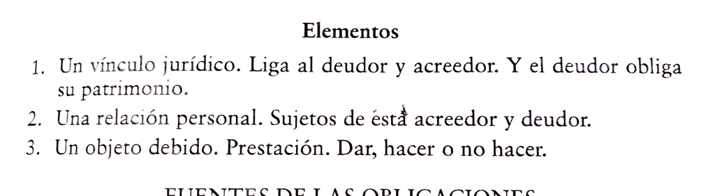

- Fuentes
  1. contrato
  2. cuasicontrato
  3. delito
  4. cuasidelito
  5. la ley
  6. para algunos, la declaración unilateral de voluntad
- Clasificación
  - Civiles y Naturales

    son civiles las que dan derecho para exigir su cumplimiento art. 1470

    son naturales las que no dan derecho para exigir su cumplimiento pero que cumplidas, autorizan para retener lo que se ha dado o pagado en razón de ellas.
    - Señale los casos de obligación natural (art. 1470)
      1. las contraídas por los **incapaces relativos**
      2. las que proceden de **actos a que faltan solemnidades**
      3. obligaciones civiles **prescritas**
      4. las que no han sido reconocidas por **falta de prueba**
    - Otros casos de oº naturales
      1. pago de intereses no estipulados en el mutuo
      2. pago de apuestas en que predomina la inteligencia
      3. multa en esponsales
      4. pago por objeto o causa ilícita a sabiendas
      5. en el beneficio de inventario cuando se paga más allá de lo recibido por herencia.
    - efecto de las oº naturales
      1. autorizan a *retener* lo pagado
      2. pueden ser *novadas*
      3. pueden ser *caucionadas*
      4. no se extinguen por sentencia
      5. no se puede alegar la excepción de cosa juzgada
  - Positivas y Negativas

    dependiendo si consisten en llevar a cabo una prestación o una abstención
  - De especie o cuerpo cierto y de género

    dependiendo de su determinación, debiendo ser a lo menos determinado en su género.
    - efectos de especie o cuerpo cierto
      1. se satisface entregando precisamente la cosa
      2. está obligado a conservar la cosa
      3. debe emplearse una diligencia que puede estar graduada conforme a si beneficia al deudor, acreedor o ambos
      4. se extingue con la pérdida de la cosa
    - efecto de género
      1. el acreedor no puede pedir determinadamente un individuo
      2. el deudor cumple entregando cualquier individuo del género determinado de una calidad a lo menos mediana
      3. el deudor puede destruir o enajenar las cosas genéricas, mientras subsistan otras para el cumplimiento de lo que se debe
      4. la perdida de algunas cosas no extingue la obligación, el género no perece
      5. no opera la teoría de los riesgos
  - De dar, hacer o no hacer

    Es de dar la que tiene por objeto *transferir* el dominio o constituir un derecho real o la mera tenencia

    Es de hacer la que tiene por objeto la *ejecución* de un hecho cualquiera, material o jurídico

    No hacer consiste en la *abstención* de un hecho que, *de otro modo sería lícito ejecutar*
  - Objeto singular y objeto múltiple

    las de objeto múltiple a su vez se clasifican en
    - de simple objeto múltiple

      se deben varias cosas copulativamente de modo que el deudor se libera prestándolas o ejecutándolas todas
    - alternativas

      se deben **varias** cosas pero que la ejecución de una de ellas *exonera* al deudor de la ejecución de las demás
      - características
        1. elección del deudor salvo estipulación en contrario
        2. acreedor no obligado a aceptar parte de una y parte de otra
        3. acreedor debe demandar en la alternativa en que se deben
        4. si son varios se debe hacer la elección de consuno
        5. pérdida parcial y culpable y la elección es del acreedor, puede pedir a su arbitrio el precio de la cosa perdida más indemnización u otra de las cosas que se debían en alternativa (sin indemnización)
        6. las cosas se deben bajo la condición de que sean elegidos
        7. será mueble o inmueble según el objeto para el pago
    - facultativas

      son aquellas que se debe **una** cosa determinada pero *concediéndose* al deudor la facultad de pagar con esta cosa o con otra que se designa.
      - efectos
        - acreedor sólo puede pedir la cosa debida
        - dación en pago pactada anticipadamente
        - puede ser mueble o inmueble
        - en caso de duda se tiene por alternativa
  - Con unidad de sujetos o pluralidad de sujetos

    con unidad de sujeto solo existe un acreedor y un deudor, lo que no exige mucho análisis, a diferencia de pluralidad sujetos que se pueden clasificar en:
    - simplemente conjuntas o mancomunadas

      son aquellas en que cada uno de los deudores es obligado solamente a su parte o cuota en la deuda y cada uno de los acreedores sólo tiene derecho para demandar su parte o cuota en el crédito.

      consecuencias = existe una pluralidad de prestaciones y vínculos independientes entre si, el objeto es física y moralmente divisible, cada deudor solo obligado al pago de su cuota y cada acreedor a su parte del crédito, la cuota del deudor insolvente no grava a sus codeudores, la interrupción de uno no afecta a los demás, la culta tampoco, excepciones personales solo por sus titulares, mora de uno no afecta los demás, nulidad de uno no afecta a los otros.
    - solidarias

      aquellas en que hay varios deudores o acreedores y la prestación recae sobre un objeto divisible, pero por disposición de la ley o expresa declaración de voluntad, cada acreedor puede demandar y cada deudor debe satisfacer el total de la obligación de manera que el pago efectuado por un deudor a cualquiera de los acreedores extingue la obligación respecto a todos.

      puede tener por fuente el testamento

      solidaridad activa = cada acreedor puede demandar el total al deudor, el cual puede pagar a cualquiera de los acreedores con tal que no haya sido demandado por uno de ellos, pago que extingue la obligación respecto a todos, la interrupción de la prescripción aprovecha a los demás.

      solidaridad pasiva = acreedor puede demandar a cualquiera de los deudores el total, el cual extingue respecto a todos los deudores si es pagada, la interrupción de la prescripción perjudica a todos, la mora de uno afecta a todos, la perdida de la cosa por uno hace solidarios en el precio y la indemnización la responde el culpable, cada deudor puede interponer las excepciones reales personales o mixtas.

      Extinción de la solidaridad:
      - muerte
      - renuncia del acreedor
    - indivisibles

      aquellas en que la prestación recae sobre un objeto que no es susceptible de división física, intelectual o de cuota.
      - activa
        1. cada acreedor puede pedir el total
        2. se transmite a los herederos
        3. el pago hecho a uno de los acreedores extingue la obligación respecto de los demás
        4. la interrupción de la prescripción de uno beneficia a los demás
        5. un acreedor no puede sin el consentimiento de los otros remitir la deuda o recibir el precio en vez de la cosa
      - pasiva
        1. se transmite a los herederos
        2. pago hecho por uno extingue la obligación de los demás
        3. la interrupción de la prescripción contra uno beneficia a los demás
        4. demandado puede pedir plazo para entenderse con los demás, salvo que solamente él pueda cumplirla
        5. la de indemnizar los perjuicios es divisible en la parte que a cada uno quepa
        6. las relaciones internas de los codeudores se rigen por las reglas de las oº simplemente conjuntas.
      - indivisibilidad de pago art. 1526
        1. acción hipotecaria
        2. deuda de especie o cuerpo cierto
        3. codeudor cuyo hecho o culpa hizo imposible cumplimiento
        4. obligación de pagar exclusivamente deuda hereditaria o testamentaria
        5. si se debe una cosa cuya división ocasione grave perjuicio al acreedor
        6. cuando la obligación es alternativa.
  - Obligaciones principales y accesorias

    principales = las que tienen una existencia propia, capaz de subsistir por si mismas

    accesorias = son las que no pueden subsistir por sí solas y suponen una oº principal a que acceden y garantizan
  - de ejecución instantánea y de tracto sucesivo

    ejecución instantánea = la prestación por su naturaleza se cumple en un solo acto

    tracto sucesivo = se cumple continuamente en el tiempo
  - puras y simples y sujetas a modalidad

    puras y simples = son aquellas que producen sus efectos desde que se contraen para siempre y sin limitaciones

    sujetas a modalidades = aquellas cuyo efectos regulares se alteran por la introducción de ciertas cláusulas que afectan el nacimiento, ejercicio, extinción o manera de ejercitar los derechos consiguientes.
    - condición

      hecho futuro e incierto del cual depende el nacimiento o la extinción de un derecho. Pueden ser expresas o tácitas, determinadas o indeterminadas (si el hecho ha de suceder se desconoce cuando), positivas (consisten en acontecer algo), negativas (no acontezca algo) físicamente imposible (contraria a las leyes naturales) moralmente imposible (prohibida por las leyes, buenas costumbres u el orden público)
      - suspensiva

        aquellas que mientras no se cumplan *suspenden el nacimiento* de un derecho
        1. positiva, física o moralmente imposible = fallida
        2. negativa, moralmente imposible = fallida
        3. negativa, físicamente imposible = no escrita
        - efectos mientras está pendiente
          1. acreedor tiene un derecho en germen al cual puede ser trasmitido, impetrar medidas conservativas y de efecto retroactivo
          2. no se puede exigir su cumplimiento (si paga puede repetirse)
          3. no tiene derecho a los frutos
          4. no tiene acción de partición
          5. tiene derecho al precio y perjuicios si se pierde la cosa por culpa del deudor
          6. no corre la prescripción
        - fallida

          nunca ha existido obligación
        - cumplida
          1. nace el derecho y la obligación correlativa
          2. opera la prescripción y la compensación
          3. opera la retroactividad
        - casos en que opera retroactivamente
          1. derechos deferidos a la criatura que está por nacer
          2. hipoteca bajo condición
          3. venta de cosa ajena
          4. tradición de cosa ajena
        - casos en que no opera retroactivamente
          1. respecto de los frutos
          2. en el caso que se haya enajenado a tercero de buena fe
          3. riesgo es del deudor, salvo mala fe
          4. contratos de tracto sucesivo
      - resolutoria

        la que con su cumplimiento extingue un derecho
        1. positiva, física o moralmente imposible = no escrita
        2. negativa, física o moralmente imposible = no escrita
        - ordinaria

          es la que consiste en un hecho futuro e incierto del cual depende la extinción de un derecho, *no consistiendo en el incumplimiento de una obligación* - opera de pleno derecho.
        - CRT

          es la que va envuelta en todo contrato bilateral y consiste en el **no cumplimiento por parte de uno de los contratantes** de lo pactado - dando al contratante diligente un dº opcional que puede ser el cumplimiento forzado de la obligación o su resolución y en ambos casos con indemnización de perjuicios.
        - pacto comisorio

          simple: es la CRT expresamente estipulada, la cual confiere a la parte diligente que haya cumplido o se encuentre llana a cumplirla, los mismos derechos señalados anteriormente.

          calificado o ipso facto: es aquel en que se estipula que si no se cumple se resolverá ipso facto el contrato. En la CV da derecho al deudor en pagar dentro de las 24 hrs, en los otros no existe este derecho para poder enervar la acción resolutoria.
        - efectos
          1. pendiente = nace el dº con todos sus atributos, sujeto al evento de extinguirse por la condición
          2. fallida = se consolida definitivamente el dº y el acto se reputa puro y simple
          3. cumplida = se extingue el dº y desaparece la oº.
             - *entre las partes* = restitución de la cosa, conserva los frutos (salvo la ley o estipulación en contra)
             - *respecto de terceros* = si es mueble no dará dº a reivindicarla contra 3º de buena fe, si es inmueble, solo podrá reivindicarla cuando la condición constaba en el título respectivo, inscrito u otorgado por escritura pública.
        - acción resolutoria

          es la que nace de la CRT y del pacto comisorio para pedir la resolución del contrato por el incumplimiento de las oº contraídas. prescribe en los 5 años (CRT) y 4 años (o menos si emana del pacto comisorio)
      - cumplimiento de las condiciones
        1. del modo en que las partes haya entendido que lo fuese
        2. se presume que dicho modo es el más racional
        3. literalmente en la forma convenida y no por equivalencia
        4. totalmente
        5. dentro de la época fijada (si es determinada)
        6. aún después de la muerte de los contratantes.
    - plazo

      es un hecho futuro y cierto del cual depende la exigibilidad o la extinción de un derecho y de sus obligaciones correlativas. el plazo cuando es resolutorio extingue la oº de pleno dº.
      - efectos
        - pendiente
          1. no puede exigirse el cumplimiento
          2. no corre prescripción
          3. no corre compensación
        - cumplido
          1. la obligación se hace exigible
          2. constituye en mora al deudor
      - extinción del plazo
        1. cumplimiento
        2. renuncia
        3. caducidad, por procedimiento concursal o la insolvencia o por la disminución o extinción de cauciones.
    - modo

      consiste en un gravamen o carga impuesta por el acreedor al deudor para que tenga por suyo el objeto de la oº debiendo aplicarlo a un fin especial o sujetarse a un determinado gravamen.
      - efectos
        1. no suspende la adquisición de la cosa
        2. el derecho no se extingue por el incumplimiento del modo (salvo que consista en una condición, contratos bilaterales)
        3. si el modo es imposible se tiene por no escrito
        4. si es imposible en la forma prevista y sin culpa del deudor se cumple por equivalencia.
        5. si se hace imposible sin culpa del deudor, la oº se reputa pura y simple.
- Efectos de las Obligaciones
  - concepto

    son los dº que la ley confiere al acreedor para obtener el cumplimiento exacto, íntegro y oportuno de la oº, cuando éste no la cumple en todo o en parte o esta en mora de cumplirla.
  - medios que tiene el acreedor para obtener el cumplimiento de la oº
    1. el dº de pedir el **cumplimiento forzado** de la oº
    2. el derecho a la **indemnización de perjuicios**
    3. los **derechos auxiliares** del acreedor (medidas conservativas, la acción subrogatoria, la acción pauliana y el beneficio de separación)
  - 1. De la ejecución forzada de la oº
       1. dº de prenda general de los acreedores, de perseguir la ejecución de una oº sobre todos los bienes raíces o muebles del deudor, presentes o futuros, excepto los inembargables y las oº naturales
       2. los acreedores podrán exigir que se vendan todos los bienes del deudor hasta concurrencia de sus créditos, intereses y costas, para que con el producto se les satisfaga íntegramente.
       3. para la ejecución forzada se requiere un título ejecutivo.
       - oº de dar
         1. mediante el uso de la fuerza pública si se encuentra en poder del deudor
         2. si se trata de dinero, se remata los bienes embargados para el pago
         3. se requiere que sea deuda líquida o posible de liquidarse, conste en un título ejecutivo, actualmente exigible, no esté prescrita
       - oº de hacer
         1. pedir que se apremie al deudor para la ejecución del hº
         2. que se autorice al acreedor para hacerlo ejecutar a expensas del deudor
         3. que el deudor le indemnice los perjuicios resultantes de la infracción del contrato
         4. se requiere que conste en un título ejecutivo, actualmente exigible, determinado o determinable (el hº), que no esté prescrito.
       - oº de no hacer
         1. si puede destruirse lo hº y es necesario para el objeto que se tuvo en vista al contratar, puede ser compelido (el deudor) a la destrucción o autorizar al acreedor para proceder a su destrucción a expensas del deudor
         2. si no es necesaria puede cumplirse por equivalencia
         3. si la destrucción no es posible, se indemnizara perjuicios
         4. requiere: titulo ejecutivo, actualmente exigible, que se convierta en la destrucción de la obra, que no esté prescrita
       - embargo

         Es la aprehensión real o simbólica de uno o más bienes del deudor por ministro de fe, por autorización judicial, para que con el producto de la realización se pague al acreedor su crédito.
         - como se realiza
           1. se verifica por la entrega real o simbólica a un depositario que designe el juez, aun que se mantengan en poder del deudor.
           2. si recae dineros, alhajas, especies preciosas o efectos públicos, deberá hacerse el depósito en el banco estado de chile a la orden del juez de la causa
           3. si recae sobre bienes raíces o derechos reales sobre ellos debe inscribirse en el CBR donde estén ubicados.
         - efectos
           1. priva al deudor de la administración de los bienes
           2. priva al deudor de la facultad de disposición (pero no del dominio)
           3. habilita al acreedor para realizar los bienes embargados y pagarse con su producto
       - prelación de crédito

         consiste en un conjunto de reglas establecidas por la ley que determinan el orden y forma en que deben pagarse los diversos acreedores de un deudor.

         Por RG existe igualdad de los acreedores. Sin embargo, existen causales de preferencias que están establecidas en consideración al crédito.
         - clases de créditos
           - Créditos de 1ª clase
             1. costas judiciales
             2. expensas funerales
             3. gastos de enfermedad
             4. gastos que incurra para poner a disposición la masa de los bienes del deudor a los acreedores
             5. remuneraciones de los trabajadores
             6. créditos del fisco en contra de entidades administradoras de fondos de pensiones.
             7. artículos necesarios de subsistencia suministrados al deudor y familia durante los últimos 3 meses
             8. indemnizaciones legales y convencionales de origen laboral
             9. créditos del fisco por impuestos de retención y recargo.
           - Créditos de 2ª clase
             1. el credito del posadero
             2. el del acreedor o empresario de transportes
             3. crédito del acreedor prendario sobre la prenda
             4. derecho legal de retención.
           - Créditos de 3ª clase
             1. Créditos hipotecarios
             2. Censos debidamente inscritos
             3. Derecho legal de retención sobre bienes raíces judicialmente declarado e inscrito en el Registro de hipotecas y gravámenes
             4. Derecho del aviador derivado del contrato de avío.
           - Créditos de 4ª clase
             1. Créditos del fisco contra recaudadores o administradores de bienes fiscales
             2. créditos de ciertas instituciones públicas contra recaudadores y administradores de sus bienes
             3. los créditos de las mujeres casadas, por bienes de su propiedad administrados por su marido
             4. los de las personas que están bajo tutela o curaduría contra sus tutores o curadores
             5. del pupilo contra el que se casa con la madre o abuela, tutora o curadora art. 511
           - Créditos de 5ª clase

             son aquellos a que la ley no confiere preferencia alguna para su pago
         - cesión de bienes

           es el abandono voluntario que el deudor hace de todos sus bienes a su acreedor o acreedores, cuando a consecuencia de accidentes inevitables no se halla en estado de pagar su deuda.
           - requisitos
             1. deudor civil y no comercial
             2. deudor de buena fe
             3. declarado judicialmente
             4. no haber incurrido en alguna causal de exclusión de la cesión de bienes
           - casos en que los acreedores no están obligados a aceptar la cesión de bienes 1617
             1. deudor enajeno, empeño o hipotecó como propios, bienes ajenos a sabiendas
             2. deudor condenado por hurto, robo falsificación u otros
             3. ha obtenido quitas o esperas de sus acreedores
             4. ha dilapidado bienes
             5. no ha hecho una exposición circunstanciada y verídica del estado de sus negocios o se ha valido de cualquier otro medio fraudulento para perjudicar a sus acreedores
  - 2. Indemnización de perjuicios

    es el derecho del acreedor para exigir del deudor el pago de una suma de dinero equivalente al beneficio que le habría reportado el cumplimiento íntegro y oportuno de la obligación.
    - clasificación
      - compensatoria

        aquella a que tiene derecho el acreedor cuando el deudor no ha cumplido su obligación o la ha cumplido imperfectamente
      - moratoria

        aquella a que tiene derecho el acreedor cuando el deudor cumplió su obligación tardíamente
    - requisitos
      - 1. **infracción de la oº**

        puede haber incumplimiento total o parcial culpable al deudor. Debe cumplir lo convenido no sólo lo expresamente estipulado, **sino todas aquellas obligaciones que por ley o costumbre** pertenecen al contrato, de forma oportuna tanto de las obligaciones principales o accesorias.
      - 2. **perjuicio causado**

        cualquier detrimento o daño que experimente el patrimonio de una persona, sea que signifique una disminución real o efectiva de él, sea que sólo importe la privación de obtener una utilidad o ganancia. Pérdida efectiva o daño emergente. pérdida de ganancia o lucro cesante.
        - evaluación de perjuicios
          - legal

            art. 1559 procede solamente en aquellas oº que tienen por objeto el pago de una cantidad de dinero y consiste en el **pago de intereses**, por la cual no se necesita probar los perjuicios y se trata de una indemnización de carácter moratoria.
          - judicial

            es la RG y procede cuando ni la ley ni las partes han fijado, se debaten en juicio ordinario su procedencia, naturaleza y cuantía.
            - clases de perjuicios

              *directos* = consecuencia inmediata y directa del incumplimiento de la obligación (**salvo estipulación contraria**)

              *previstos* = los que las partes pudieron prever al tiempo del contrato (**siempre**)

              *imprevistos* = los que no pudieron razonablemente preverse cuando la obligación se contrajo (**con dolo o culpa grave**)

              *indirectos* = aquellos que directamente provienen de una causa extraña y solo remotamente del incumplimiento (**nunca**)
            - clases de daño

              daño material = disminución de patrimonio

              daño moral = molestia o dolor

              daño moral patrimonial = desmejoramiento patrimonial debido al daño moral
          - convencional art. 1553

            se trata de la **cláusula penal** es aquella en que una persona, para asegurar el cumplimiento de una obligación, se sujeta a una pena, que consiste en **dar hacer algo en caso de no ejecutar o de retardar la obligación principal**
            - características
              - accesoria
              - condicional
              - expresa
              - garantía o caución personal
              - puede ser moratoria o compensatoria
              - es una evaluación anticipada de perjuicios
              - hace presumir de derecho la existencia de perjuicios
              - puede otorgarla un tercero
            - efectos
              1. debe existir mora del deudor
              2. si se cumple parcialmente y se acepta por parte del acreedor, la pena se rebaja en forma parcial
              3. antes de la mora el acreedor solo puede demandar la obligación principal
              4. después, puede a su arbitrio, la obligación principal o la pena, a menos que la pena se haya estipulado por el simple retardo o que por el pago de la pena no se extingue la obligación principal
              5. en el caso de la transacción art. 2463 procede la pena y cumplimiento de la obligación principal, al igual que las hipótesis excepcionales establecidas en el nº 4.

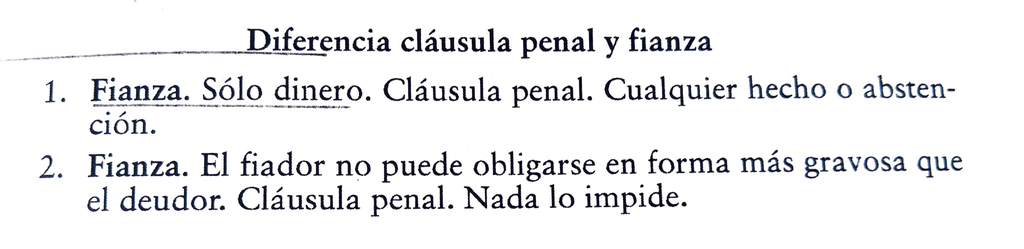

      - reducción de la pena
        1. cuando acreedor acepta un pago parcial
        2. cuando la pena es enorme (contratos conmutativos = si excede del duplo de la obligación; mutuo = si excede los intereses penales; demás casos entregado a la prudencia del juez)
    - 3. **Que se impute a dolo o culpa del deudor**
      - grados de imputación:
        - Caso fortuito o fuerza mayor
        - Culpa
        - Dolo
      - caso fortuito o fuerza mayor

        es un imprevisto que no es posible resistir. Exime de responsabilidad al deudor respecto a su incumplimiento o retardo. Si es parcial lo exime respecto a esa parcialidad.

        requisitos:
        - debe ser *ajeno*
        - imprevisto al momento de la celebración
        - irresistible o insuperable
        - imposibilidad *permanente*

        efectos:
        - deudor queda *exento* de responsabilidad
        - no responde del retardo
        - si deudor no puede cumplir *parte*, queda liberado de esta parte
          - no exime
            1. estipulación expresa de las partes
            2. caso fortuito por culpa del deudor
            3. caso fortuito durante la mora
            4. caso de hurto y robo
        - teoría de la imprevisión

          se trata de una eximente de responsabilidad basada en la ocurrencia de un acontecimiento en condiciones generales, imprevisible, ajeno a la voluntad de las partes trastorna gravemente el equilibrio de las prestaciones de un contrato de tracto sucesivo, haciéndolo excesivamente oneroso el cumplimiento
        - teoría de los riesgos

          es la que determina quien sufre en definitiva la pérdida de la cosa debida en los contratos bilaterales cuando está pendiente el cumplimiento de una obligación de dar o entregar una especie o cuerpo cierto.

          RG = el riesgo del cuerpo cierto cuya entrega se debe es siempre del acreedor
      - imputación por dolo o culpa
        - dolo

          consiste en la intención positiva de inferir injuria a la persona o propiedad de otro

          Triple ámbito de aplicación del dolo:
          - Como vicio del consentimiento
          - Como agravante de la responsabilidad contractual
          - Como elemento constitutivo de la responsabilidad extracontractual
          - efectos
            1. da lugar a la indemnización de perjuicios
            2. agrava la responsabilidad del deudor
            3. origina responsabilidad solidaria
            4. puede ser renunciada (no anticipadamente)
          - características
            - no se presumen, salvo:
              - albacea (art. 1301)
              - ocultación del testamento (art. 968 n°5)
              - la apuesta (art. 2261)
              - medidas prejudiciales (art. 280 CPC)
            - no se puede condonar anticipada
            - equivale a culpa grave
            - el dolo no se gradúa
            - las partes pueden atenuar la responsabilid del dolo
            - se presume de hechos
        - culpa

          es la falta de diligencia en el cumplimiento de una obligación o en la ejecución de un hecho cualquiera
          - clasificación
            - culpa incontraendo

              la que proviene de un pacto tácito al celebrar un contrato que no se perfeccionó o resulto ineficaz
            - culpa contractual

              es la que incide en el cumplimiento de obligaciones contractuales, cuasi contractuales y legales
            - culpa extracontractual

              falta de cuidado general que hay que emplear en la ejecución de hechos para evitar perjuicios a terceros
          - clases (o graduaciones)
            - culpa grave

              es la que consiste en no manejar los negocios ajenos con aquel cuidado que aún las personas negligentes y de poca prudencia suelen emplear en sus negocios propios
              - responden
                1. todo deudor, aun cuando el acreedor esté en mora
                2. deudor en contratos que solo son útiles al acreedor
                3. cuando así lo han estipulado expresamente las partes
            - culpa leve RG

              es la falta de aquella diligencia y cuidado que los hombres emplean ordinariamente en sus negocios propios.
              - responden
                1. deudor en los contratos onerosos
                2. los que administran bienes ajenos
                3. el que tiene el uso y goce de una cosa
                4. cuando la ley le impone
                5. cuando se ha estipulado expresamente
            - culpa levísima

              es la falta de aquella esmerada diligencia que un hombre juicioso emplea en la administración de sus negocios importantes. Responde de esta culpa el deudor en aquellos contratos en que el es el único beneficiario
    - 4. **Que el deudor esté constituido en mora**

         La mora es el retardo culpable en el cumplimiento de una obligación, más allá del plazo fijado para su ejecución o que persiste después del requerimiento
      - requisitos
        1. retardo en el cumplimiento
        2. retardo culpable (dolo o culpa)
        3. interpelación
           - contractual
             - expresa = cuando no ha cumplido dentro del término estipulado (salvo que la ley lo establezca como en el caso de la cosa arrendada)
             - tácita = cuando la cosa no ha podido ser dada o ejecutada sino dentro de cierto lapso
           - extracontractual
             - cuando ha sido reconvenido judicialmente, desde la notificación
        4. que el acreedor haya cumplido, por su parte, la obligación o manifieste estar llano a cumplirla
        - Efectos de la mora:
          - Impone al deudor la obligación de indemnizar perjuicios
          - Hace el deudor responsable del caso fortuito que sobreviene durante la mora
          - Pone a cargo del deudor el riesgo de la especie o cuerpo cierto que se debe
        - Efectos de la mora del **acreedor**:
          - Atenúa la responsabilidad del deudor, sólo responde de culpa lata o dolo
          - El acreedor debe indemnizar los perjuicios
          - No exonera al deudor. Debe pagar por consignación
      - Excepción: la mora purga la mora

        en los contratos bilaterales, ninguno de los contratantes está en mora dejando de cumplir lo pactado, mientras el otro no lo cumple por su parte, o se allana a cumplirlo en la forma y tiempo debido.
      - efectos
        1. impone al deudor la obligación de indemnizar perjuicios
        2. hace al deudor responsable del caso fortuito que sobreviene durante la mora.
        3. pone a cargo del deudor el riesgo de la especie o cuerpo cierto que se debe.
    - inexistencia de una cláusula de irresponsabilidad que exima de indemnización de perjuicios en caso de incumplimiento.
  - 3. Derechos auxiliares del acreedores
    - 1. medidas conservativas
      - guarda y aposición de sellos
      - derechos del acreedor condicional
      - derecho legal de retención del arrendatario, vendedor, mandatario, depositario, comodatario
      - la herencia yacente
      - medidas precautorias
      - fideicomisario, asignatario y el acreedor condición
    - 2. acción subrogatoria u oblicua

      consiste en el ejercicio por los acreedores de acciones y derechos que competen al deudor para incorporar al patrimonio de éste, bienes en que hacer afectivos sus créditos
      - requisitos
        1. disposición legal que la conceda, deudor insolvente
        2. crédito cierto y exigible
        3. deudor se rehuse o descuide el ejercicio de sus acciones
        4. que la negativa o desidia perjudique al acreedor
      - casos que procede
        1. derechos reales de usufructo, prenda e hipoteca (excp. los personalísimos)
        2. derecho legal de retención
        3. contrato de arrendamiento
        4. en acciones contra aquellos que por hecho o culpa suya pereció la cosa
        5. respecto a la repudiación de una herencia o legado
      - efectos
        1. demandado puede oponer las excepciones que tenía contra el deudor
        2. sentencia produce cosa juzgada respecto del deudor
        3. los bienes que ingresan benefician a todos los acreedores
    - 3. acción revocatoria o pauliana

      es la que tiene los acreedores para obtener que se deje sin efecto las enajenaciones hechas por el deudor en fraude o con perjuicio a sus derechos
      - requisitos
        1. perjuicio de los acreedores
        2. fraude o mala fe (actos gratuitos = solo del deudor, onerosos = del deudor y del tercero con quien contrata)
      - efectos
        1. se reintegra la cosa
        2. sólo aprovecha los acreedores, no el deudor
        3. sólo a los acreedores que han sido parte
        4. sólo hasta el monto debido
        5. los terceros pueden enervar, pagando
        6. prescribe en un año
    - 4. beneficio de separación

      consiste en un derecho auxiliar de los acreedores hereditarios y testamentarios para pedir que no se confundan los bienes del difunto con los bienes del heredero. Con esto, tendrán derecho a que de los bienes del difunto se les cumplan las obligaciones hereditarias o testamentarias con preferencia a las deudas propias del heredero
- Modos de extinguir las obligaciones
  - la resciliación o mutuo disenso

    es una convención entre acreedor y deudor, por la cual ambos, teniendo capacidad de disposición, consienten en extinguir la obligación, dejando sin efecto el contrato

    No procede respecto: mandato, arrendamiento
  - el pago o solución

    es la prestación de lo que se debe y de todo lo que se debe. Se trata de un acto jurídico bilateral.
    - quién puede pagar
      - el deudor
      - una persona interesada
      - un extraño (no interesado)
      - requisitos respecto a la obligación de dar
        1. que sea dueño de la cosa o
        2. que tenga capacidad para enajenar
        3. solemnidades legales
    - a quién se debe realizar el pago?
      - al acreedor, herederos, legatarios o cesionarios
      - al representante del acreedor
      - al poseedor del crédito
    - forma de pago

      debe ser de conformidad al tenor de la obligación, de forma íntegra, y específico, con la misma cosa debida (especie o cuerpo cierto).
      - excepciones
        1. obligaciones modales
        2. obligaciones facultativas
        3. dación en pago
        4. total, salvo caso de convención en contrario
        5. la parte no disputada
        6. en la compensación
    - lugar del pago
      - lugar designado por la convención
      - especie o cuerpo cierto, en lugar en que exista al constituirse la obligación
      - si es otra cosa, en el domicilio del deudor al constituirse la obligación
    - qué se debe pagar?
      - **oº de especie o cuerpo cierto**

        la cosa debe entregarse en el estado en que se encuentra
        - excepciones
          - rescisión del contrato y la indemnización de perjuicios
            1. si la cosa se deterioró por culpa del deudor
            2. por persona por la cual él es responsable,
            3. que hayan ocurrido después que el deudor estuviere en mora
            4. que no provengan de caso fortuito que hubiese ocurrido igualmente en manos del acreedor
          - solamente indemnización de perjuicios
            1. si el acreedor prefiere llevarse la especie
            2. deterioro no pareciere de importancia
          - pago válido en el estado que se encuentre pero el acreedor puede exigir que se le ceda la acción que tenga su deudor contra tercero
            1. deterioro ha sobrevenido antes de que el deudor se constituyera en mora pero por culpa de un tercero por la cual no es responsable
        - no responde de la pérdida
          1. por caso fortuito
          2. estando en mora, pero de haberse cumplido oportunamente la obligación la cosa se hubiere deteriorado igualmente en poder del acreedor
          3. por hechos de terceros que no responde el deudor
          4. destrucción de la cosa ofrecida al acreedor
      - **oº de genero**
        1. acreedor no puede pedir un individuo determinado
        2. deudor puede pagar con un individuo indeterminado de un género determinado, de una calidad de a lo menos mediana (con excp. mutuo: debe ser del mismo genero y calidad)
      - **oº de dinero**
        1. sólo suma numérica
        2. puede ser reajustable
        3. se puede pactar en moneda extranjera o valor oro
    - imputación del pago

      es su aplicación a determinada obligación cuando entre acreedor y deudor existen varias obligaciones de la misma naturaleza, como intereses y el pago que efectúa no es suficiente para satisfacer su totalidad
      - requisitos
        1. varias obligaciones o una que produzca intereses
        2. entre los mismos acreedores y deudores
        3. que sean de la misma naturaleza
        4. que el pago sea insuficiente para todas
    - prueba
      1. incumbe al deudor
      2. limitación prueba testimonial si es superior a 2 UTM
      3. por recibo del pago, el cual tiene dº a exigir según C. de Com.
    - modalidades del pago
      - pago por consignación

        es el depósito de la cosa que se debe, con las formalidades necesarias, en manos de un tercero, hecho en virtud de repugnancia o no comparecencia del acreedor a recibirla, o de la incertidumbre acerca de su persona.
        - etapas
          - oferta

            es el acto por el cual el deudor manifiesta su intención de cumplir la obligación
          - consignación
            1. en la cuenta del TRB
            2. en la Tesorería comunal
            3. departamento agrícola del Banco Estado
            4. ferias, casas de martillo o almacenes de depósito del lugar en que debe hacerse el pago, según la naturaleza de la cosa
            5. en su defecto, al que nombrare el juez
          - declaración de suficiencia del pago

            la realiza el juez y extingue la obligación.

            no la declarará cuando no comprenda la cosa debida o cuando se omitieron los requisitos de la oferta y consignación.
      - pago con subrogación

        es una ficción legal por la cual el crédito que ha sido pagado con dineros proporcionados por un tercero, y que, por consiguiente se extingue respecto del acreedor, se reputa subsistir con todos sus accesorio, en provecho del tercero para asegurarle el reembolso de lo pagado.
        - Requisitos:
          - pago de deuda ajena
          - debe ser voluntario
          - con fondos propios
          - quien paga debe quedar en la misma situación jurídica que el acreedor
        - casos de subrogación legal (aún contra la voluntad del acreedor)
          1. del acreedor que paga a otro acreedor en razón de un privilegio o hipoteca
          2. del que habiendo comprado un inmueble es obligado a pagar a los acreedores hipotecarios
          3. del que paga una deuda a la que se halla obligado solidariamente o subsidiariamente
          4. del heredero beneficiario que paga las deudas de la herencia
          5. del que paga deuda ajena, consintiéndolo expresa o tácitamente con el deudor
          6. del que ha prestado dinero al deudor para el pago, constando en escritura pública
        - subrogación convencional

          es aquella que se efectúa en virtud de una convención del acreedor y del tercero **no interesado** que le paga, subrogándole en todos los derechos y acciones que le corresponden
      - pago por cesión de bienes

        es el abandono voluntario que el deudor hace de todos sus bienes a su acreedor o acreedores cuando, a consecuencia de accidentes inevitables, no se halla en estado de pagar sus deudas.
      - pago con beneficio de competencia

        es el que se concede a ciertos deudores para no ser obligados a pagar más de lo que buenamente puedan, dejándoseles en consecuencia lo indispensable para la modesta subsistencia, según clase y circunstancias, y con cargo de devolución, cuando mejoren de fortuna
        - ¿quienes pueden invocar este beneficio?
          1. ascendientes y descendientes
          2. cónyuge
          3. hermanos
          4. consocios
          5. donante, para cumplir la donación
          6. el que hizo cesión de bienes
  - dación en pago

    es una convención entre acreedor y deudor por la cual el deudor paga con una prestación diversa a la que se obliga.

    Efectos:
    - Si se considera novación = extingue el pago y no revive aunque la cosa sea evicta
    - Si se la considera modalidad = revive la obligación si es evicta
  - novación

    es la sustitución de una nueva obligación a otra anterior, la cual queda extinguida. Es convención y contrato de carácter extintivo y sustitutivo.
  - remisión

    Consiste en una convención en la cual el acreedor renuncia total o parcialmente de su crédito
  - compensación

    consiste en un modo de extinguir las obligaciones en que ambas partes comparten la calidad de acreedor y deudor, extinguiéndose ambas obligaciones hasta la concurrencia de la de menor valor, reuniéndose los demás requisitos legales.

    Requisitos:
    - partes recíprocamente acreedoras y deudoras
    - obligaciones de igual naturaleza
    - obligaciones deben ser exigibles
    - liquidez de ambas deudas

    Hechos que impiden la compensación:
    - que la obligación sea natural
    - condición suspensiva pendiente
    - plazo no vencido

    Obligaciones no compensables:
    - demanda de restitución de un despojo
    - demanda de indemnización por violencia o fraude
    - demanda de alimentos
  - confusión

    modo de extinguir las obligaciones que, opera de pleno derecho y que se produce cuando en una misma persona concurren las calidades de acreedor y deudor
  - pérdida de la cosa que se debe

    se produce cuando la cosa se destruye, desaparece, ignorándose si existe y cuando deja de estar en el comercio. Puede producir o la responsabilidad del deudor o liberarlo de ella.
    - lo libera de responsabilidad
      1. cuando es producida por caso fortuito o fuerza mayor
      2. cuando la cosa se destruye estando en poder del deudor, después de haber sido ofrecida al acreedor y durante el retardo de éste en recibirla (mora del acreedor)
    - produce la responsabilidad del deudor
      1. hecho o culpa suyo
      2. se produce por fuerza mayor o caso fortuito durante mora de el
      3. cuando el deudor ha tomado para sí la responsabilidad
      4. pérdida de la cosa por caso fortuito o fuerza mayor, en manos de quién la ha hurtado o robado (aun cuando se hubiera producido igualmente en manos del acreedor)
  - prescripción

    es un modo de *extinguir* las acciones y derechos ajenos por no haberse ejercido dichas acciones y derechos durante cierto lapso de tiempo y concurriendo los demás requisitos legales, es decir, no extingue la obligación civil propiamente tal sino que simplemente la transforma en natural, extinguiendo la acción para exigir su cumplimiento.
    - Requisitos:
      - 1. Acción debe ser prescriptible
           - son imprescriptibles
             1. la acción de reclamación de estado civil
             2. acción para pedir la destrucción de una obra nueva que corrompa el aire o la haga conocidamente dañoso
             3. la acción de divorcio, separación judicial y nulidad del matrimonio
             4. acción para pedir la partición
      - 2. Debe ser alegada
        - Salvo: acción ejecutiva, en materia penal
      - 3. Que no se haya interrumpido
        - natural = por el hecho de reconocer el deudor la obligación, expresamente o de forma tácita
        - civil = dda judicial notificada
          - Efectos de la interrupción:
            - detiene el curso de la prescripción
            - hace perder todo el tiempo trascurrido
            - son relativos, salvo solidaridad o indivisibilidad
      - 4. Que no esté suspendida

        se suspende a favor de:
        - los menores
        - dementes
        - sordos
        - sordomudos
        - potestad paterna, tutela o curatela
        - mujer casada en soc. conyugal
        - siempre entre cónyuges
      - 5. Transcurso del tiempo
        - se cuenta, por rg., desde que se hizo exigible
        - el plazo por rg. es legal
        - forma de contar establecida por el legislador art. 48 y ss.
  - 1. Prescripciones de largo tiempo
       - acciones de obligaciones
         1. ejecutivas = 3 años
         2. ordinarias = 5 años
       - acciones de obligaciones accesorias

         junto con la obligación principal 2516
       - acciones propietarias
         - toda acción por la que se reclama un derecho se extingue por la prescripción adquisitiva de ese mismo derecho. Reivindicatoria: 2 y 5, 10 años (PAE)
         - petición de herencia: 5 y 10 años (dependiendo si es heredero putativo)
         - servidumbre: 3 años
  - 2. Prescripciones de corto tiempo
    - presuntivas de pago
      1. honorario de profesionales liberales: 2 años
      2. mercaderes, artesanos, servicios accidentales: 1 años
      3. impuestos: 3 años. 6 sujetos a declaración
    - especiales
      1. despojo violento, redhibitoria muebles: 6 meses
      2. posesorias rebaja del precio: 1 año
      3. reforma de testamento, pacto de retroventa, responsabilidad extracontractual: 4 años
  - caducidad

    es una sanción legal que consiste en la extinción de un derecho por no haberse ejercido o cumplido una formalidad legal dentro del plazo fatal que la misma ley establece

# 6. Fuentes de las Obligaciones

- conceptos preliminares
  - convención

    acto jurídico bilateral que tiene por finalidad crear, modificar o extinguir derechos y obligaciones
  - contrato

    es un tipo de convención, es decir, un acto jurídico bilateral que tiene por finalidad crear derechos y obligaciones correlativas, en la cual una o ambas partes se obligan con la otra a satisfacer una necesidad jurídica que consiste en la realización de una prestación, la cual puede consistir en un dar, hacer o no hacer

## 6.1. Contratos en General

- clasificación
  - unilaterales y bilaterales
    1. unilateral = una de las partes se obliga para con otra que no contrae obligación alguna. Mutuo, comodato, prenda, depósito (contratos reales)
    2. bilaterales = las partes contratantes se obligan recíprocamente. Compraventa, arrendamiento, transacción
    - importancia
      - **CRT**
      - **teoría de los riesgos**
      - **la mora purga la mora**
  - gratuitos y onerosos
    1. gratuitos = sólo tiene por objeto la utilidad de una de las partes, sufriendo la otra el gravamen. Comodato, donación, depósito
    2. oneroso = tiene por objeto la utilidad de ambos contratantes, gravándose cada uno en beneficio del otro. Permuta, compraventa, mutuo con interés
    - importancia
      - **acción pauliana**
      - **determinar grado de culpa**
      - **error en la persona**
      - **saneamiento de la evicción**
  - conmutativos y aleatorios
    1. conmutativos = cada una de las partes se obliga a dar o hacer una cosa que se mira como equivalente a lo que la otra parte debe dar o hacer a su vez (se miran como equivalentes el sacrificio y el provecho)
    2. aleatorios = cuando el equivalente consiste en una contingencia incierta de ganancia o pérdida
  - principales, accesorios y dependientes
    1. principales = aquellos que subsisten por sí mismos, sin necesidad de otra convención
    2. accesorios = cuando tienen por objeto asegurar el cumplimiento de una obligación principal, de manera que no puedan subsistir sin ella
    3. dependientes = no aseguran el cumplimiento. Capitulaciones matrimoniales, están subordinados en cuanto a sus efectos a otro contrato
  - nominados e innominados
    1. nominados = tienen un nombre y una reglamentación legal
    2. Innominados = son creados por las partes
  - consensuales, reales y solemnes
    1. consensuales = se perfeccionan por el solo consentimiento
    2. reales = se perfeccionan por la entrega o tradición de la cosa. Comodato, depósito, mutuo
    3. solemnes = está sujeto a ciertas formalidades, sin las cuales no producen ningún efecto civil, este carácter es dado por la ley. Instrumento público o privado, escrituración, presencia de un funcionario
  - de ejecución instantánea y de tracto sucesivo
    1. ejecución instantánea = la obligación por su naturaleza solo puede cumplirse en un solo acto
    2. tracto sucesivo = la obligación por su naturaleza debe ser cumplida sucesivamente en el tiempo
  - de libre discusión y adhesión
    1. libre discusión = ambas partes fijan las condiciones
    2. adhesión = una de las partes fija las condiciones y la otra se limita a prestar su aprobación
  - individuales y colectivos
    1. individuales = requieren el consentimiento unánime de todas las partes
    2. colectivos = aquellos que obligan no solo a los que concurrieron a él, sino a los que se agregan al mismo grupo
- autocontrato

  es el que celebra una persona consigo misma y en el cual actúa a la vez por sí y como representante de otro y como representante de ambas.
- efectos de los contratos
  - entre las partes
    1. es una ley para los contratantes y no puede ser invalidado sino por su mutuo disenso o causales legales art. 1545
    2. buena fe y obligan a todas las cosas que emanan de su naturaleza o que por la ley o costumbre pertenezcan a el art. 1546
  - respecto a terceros
    - absolutos

      efecto relativo de los contratos, nunca van a estar en relación con las partes.
      - excepción
        - actos de familia
        - contratos colectivos
        - estipulación a favor de otro

          es un contrato en que una de las partes (estipulante), conviene con la otra (promitente), que ésta realizará una determinada prestación en favor de un 3º extraño a la convención (beneficiario). p. ej. contrato de seguro
        - promesa por otro

          es una convención en que uno de los contratantes se compromete a dar, hacer o no hacer alguna cosa por una tercera persona de quien no es legítimo representante art. 1450
    - relativos

      entran en la relación con las partes con posterioridad. ej. los herederos, los legatarios
      - sucesores a título universal

        representan al causante, identificándose con él
        - excepción
          - obligaciones intrasmisibles
          - contratos intuito personae
          - cuando se ha estipulado expresamente
      - sucesores a título singular
        1. sucesor hace suyas las ventajas y soporta los gravámenes p. ej. hipoteca
        2. deben ser anteriores a la adquisición
        3. deben referirse al bien adquirido
      - acreedores
        1. caso de la acción pauliana o revocatoria
        2. impugnación por simulación
  - teoría de la inoponibilidad

    es la ineficacia respecto de terceros de un derecho nacido como consecuencia de la celebración o de la declaración de nulidad de un acto
    - **por defecto de forma**
      - por falta de *publicidad*
        1. falta de inscripción de embargos o precautorias en inmuebles
        2. falta de inscripción de la sentencia que declara la prescripción adquisitiva de inmuebles
        3. falta de anotación marginal de la contraescritura
        4. falta de publicación e inscripción del decreto de interdicción
        5. en la cesión de derechos, no produce efecto alguno mientras no ha sido notificada por el cesionario al deudor o aceptado por éste
      - por falta de *fecha cierta*

        art. 1703 CC la fecha de instrumento privado no se cuenta respecto de terceros sino desde:
        - el fallecimiento de uno de los que han firmado
        - el día en que ha sido copiado en un registro público
        - que conste haberse presentado en juicio
        - que haya tomado razón de él o le haya inventariado un funcionario competente, en carácter de tal
    - **por defecto de fondo**
      - casos
        - por fraude

          es el caso de la acción revocatoria o pauliana
        - lesión de derechos adquiridos

          la rescisión del decreto de posesión efectiva
        - lesión de asignaciones forzosas

          la acción de reforma de testamento
        - por falta de concurrencia
          1. la venta de cosa ajena
          2. los límites del mandato
          3. inoponibilidad de la nulidad en los casos de sociedad y matrimonio
- interpretación de los contratos
  1. se debe estar más a la intención de las partes que a lo literal del contrato
  2. los términos del contrato solo se aplican a la materia de que se trata, por más generales que sean
  3. se prefiere el sentido en que la cláusula no produzca efecto alguno
  4. se deberá preferir la interpretación que mejor cuadre con la naturaleza del contrato, a menos que se señale lo contrario. Las cláusulas de uso común se presumen.
  5. se interpretan las cláusulas dando el mejor sentido que convenga al contrato en su totalidad. Se pueden interpretar con otro contrato entre las mismas partes sobre la misma materia. También por la práctica que hacen las partes o una con aprobación de la otra
  6. en caso de que se ejemplifique con un caso, una obligación , no se entiende limitarla a los demás casos que naturalmente se extiende
  7. en el defecto de las normas anteriores se interpretan las cláusulas ambiguas a favor del deudor. Pero aquellas que se hayan dictadas por una de las partes se entenderán contra ella cuando se deba a una falta de explicación de su parte.

## 6.2. Contratos en Particular

- promesa

  contrato en virtud del cual dos o más personas se obligan a celebrar un contrato futuro, concurriendo los requisitos legales

  Requisitos:
  - debe constar por escrito
  - que el contrato prometido no sea de aquellos que las leyes declaran ineficaces
  - debe contener un plazo o condición
  - que se especifique de tal manera que solo falten la tradición o solemnidad que las leyes prescriben
- compraventa

  es un contrato en que una de las partes se obliga a dar una cosa y la otra a pagarla en dinero
  - Características:
    - principal
    - nominado
    - bilateral
    - oneroso
    - por rg. conmutativo
    - por rg. consensual
    - TTD
  - elementos
    - consentimiento libre y espontáneo (salvo la venta forzada)
      - Debe recaer sobre:
        - la cosa
        - el precio
        - la naturaleza del contrato
    - la cosa (comerciable, determinada o determinable, real, no pertenecerle al comprador)
    - precio fijado en dinero
    - solemnidades en algunos casos
  - casos de compraventa solemnes
    - por escritura pública
      1. bienes raíces (salvo Serviu 14.171, caso de compraventa b. raíz por escritura privada)
      2. Servidumbre
      3. censos
      4. sucesión hereditaria
    - con arras
      - como garantía de la celebración o ejecución del contrato
      - como parte del precio o en señal de quedar convenidos

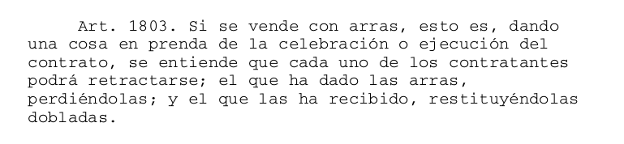

  - solemnidades
    - legales
      - ordinarias
        - escritura pública en el caso de los bienes raíces, servidumbres, censos, derecho de herencia (salvo 14.171 escritura privada, firmada ante notario y protocolizada más tardar el día ss.)
        - venta de inmuebles por adherencia y destinación

        la tradición no es solemnidad en ningún caso. La solemnidad sólo es la escritura pública
      - especiales

        son aquellas que están establecidas en atención a la calidad o estado de la persona que vende el bien, como es en el caso de los incapaces, venta b. raíces del hijo (escritura pública más autorización judicial) y el caso de autorización judicial más la subasta pública (venta de b. raíces del pupilo por parte de su curador)
    - voluntarias

      los que las partes establezcan, su omisión no produce la nulidad, solamente se tendrá como consensual
    - venta forzada en juicio ejecutivo

      se consideran contrato de compraventa, juez actúa como representante legal del vendedor o deudor, y el precio se fija mediante la puja de los interesados (mejor postor)
  - efectos
    - obligaciones del vendedor
      - 1. entregar la cosa
        - conferir al comprador la posesión legal y material de la cosa
        - si la cosa consiste en especie o cuerpo cierto además tiene la obligación de conservar la cosa hasta su entrega (salvo que sea de ejecución instantánea)
        - forma de entregar
          - muebles art. 684
          - inmuebles art 686
        - momento de entrega
          - tan pronto quede perfecto
          - una vez cumplido el plazo, modo o estipulación convenida
        - lugar de entrega
          - lugar convenido
          - donde se encontraba la especie o cuerpo cierto
          - en el domicilio del deudor
        - gastos de la entrega
          - vendedor = gastos para poner la cosa en disposición de entregarla
          - comprador = trasporte después de efectuada la entrega
      - 2. saneamiento
        - evicción

          se produce cuando el comprador es privado de todo o parte de la cosa por sentencia judicial **anterior** a la compra

          Consiste en que el vendedor tiene la obligación de defender al comprador contra terceros (obligación de amparo) que reclamen derechos sobre la cosa e indemnizarlo si la evicción se produce

          tiene dos etapas:
          - obligación de amparo = defender al comprador en juicio
          - obligación de indemnización = si se produce la privación total o parcial
          - total
            1. restitución del precio, aunque haya disminuido su valor, salvo que se deba a deterioros que se haya aprovechado el vendedor
            2. costal legales
            3. costal judiciales, salvo caso del comprador contumaz (vendedor citado se allana y comprador sigue adelante perdiendo juicio)
            4. pago de frutos, salvo caso del comprador contumaz
            5. aumento de valor de la cosa
               - causas naturales, transcurso del tiempo = si estaba en buena fe con tope de 1/4 parte del precio de la venta
               - mejoras = si estaba en buena fe, necesarias y útiles que no hayan sido abonadas por el que obtuvo la evicción
          - parcial
            1. si la parte evicta es tal que no habría comprado sin ella tiene derecho a pedir la rescisión de la venta
            2. si la parte no es tal o no se desee pedir su rescisión, tiene derecho a pedir la evicción parcial (restitución del precio parcial)
            3. corresponde no solo al vendedor directo sino los antecesores a él en el dominio
        - vicios redhibitorios

          derecho que tiene el comprador para que se rescinda la venta o se rebaje proporcionalmente el precio por los vicios ocultos de la cosa vendida, raíz o mueble
          - efectos
            1. acción redhibitoria (acción resolutoria del contrato)
            2. quanti minoris o estimatoria, acción para pedir restitución proporcional del precio
          - extinción
            - renuncia

              Es un elemento de la naturaleza por lo que puede ser renunciado por su comprador, siempre que no haya estado en mala fe
            - prescripción
              - acción redhibitoria
                - 6 meses muebles
                - 1 ano inmuebles
              - quantis minoris
                - 1 muebles
                - 18 inmuebles
                - en el caso de que la cosas sea enviada a un lugar distante, se contara desde la entrega mas el termino de emplazamiento
            - ventas forzadas

              a menos que el vendedor no pudiendo o no debiendo desconocer los vicios no los hubiera declarado a petición del comprador
    - obligaciones del comprador
      1. recibir la cosa
      - efectos de la mora del comprador en recibir la cosa:
        - abonar perjuicios
        - vendedor solo responderá de dolo o culpa grave
      2. pagar el precio
  - Pactos Accesorios:
    - Pacto comisorio
    - Pacto de retroventa
    - Pacto de retracto
    - Otros pactos conforme a las rg.
- permuta

  Es el contrato por el cual las partes se obligan mutuamente a dar una especie o cuerpo cierto por otro

  Por rg. se aplican las normas sobre la CV en lo que no sea contrario a su naturaleza
- cesión de derechos

  Consiste en el traspaso de un derecho por parte de su titular a otra persona por un acto entre vivos
  - cesión de créditos personales

    Puede ser clasificada como a) al portador, b) a la orden, y, c) nominativo. El CC regula esta ultima, las dos primaras se encuentran reguladas por el C de Com.

    Se perfecciona por la entrega del título, anotándose en el documento el traspaso del derecho en la escritura, nombre del cesionario y firma del cedente, puede consistir en una entrega real o simbólica.

    Respecto al deudor de dicho crédito debe ser notificado judicialmente o haber aceptado (expresa o tácitamente)
  - cesión del derecho de herencia o legado

    Procede una vez que se encuentre abierta la sucesión (luego de la muerte del causante), que se traspase toda la herencia o una cuota de ella, que sea hecha por el heredero o un tercero, y que sea a título oneroso.
  - cesión de derechos litigiosos

    Son aquellos derechos cuya existencia es discutida en juicio, evento incierto de la litis, solo le corresponde al demandante. Se efectúa apersonándose el cesionario al juicio, acompañando el título de la cesión
- Arrendamiento

  Es un contrato en que las partes se obligan recíprocamente, la una a conceder el goce de una cosa, o a ejecutar una obra o prestar un servicio, y la otra a pagar por este goce, obra o servicio un precio determinado

  Características:
  - nominado
  - bilateral, oneroso y conmutativo
  - mera tolerancia
  - consensual
  - acto de administración
  - trato sucesivo
  - principal

  Obligaciones del arrendador:
  - entregar la cosa
  - mantenerla en el estado de servir
  - librar al arrendatario de toda turbación o embarazo en el goce la cosa
  - que la cosa sirva para los fines que se tuvieron en vista al contratar

  Obligaciones del arrendatario:
  - pagar el precio o renta
  - usar la cosa según los términos del contrato
  - cuidar la cosa como un buen padre de familia
  - efectuar las reparaciones locativas
  - restituir la cosa al término del arrendamiento
- El Contrato de Mandato

  Características:
  - nominado
  - principal
  - generalmente consensual
  - naturalmente oneroso
  - bilateral
  - es solemne
  - mandatario obra por cuenta y riesgo del mandante
  - el mandato es un ctto. de confianza

    La representación no es de la esencia de mandato. El encargo debe consistir en la ejecución de actos jurídicos.

  Obligaciones del mandatario:
  - ejecutar el mandato
  - rendir cuenta
  - indemnizar los perjuicios causados al mandante

  Obligaciones del mandante:
  - cumplir las obligaciones contraídas por el mandatario
  - proveer al mandatario lo necesario para cumplir el mandato
  - indemnizarle los gastos y perjuicios en que haya incurrido por causa del mandato
  - pagar la remuneración convenida o la usual
- El ctto. de Fianza

  Requisitos:
  - consentimiento expreso
  - capacidad
  - obligarse a dar una suma de dinero
  - existencia de una obligación ppal a la cual accede

  Calidades que debe reunir el fiador:
  - capacidad
  - solvencia
  - domicilio

  Casos en que es obligatorio rendir fianza:
  - cuando así se hubiere estipulado
  - cuando la fortuna del deudor ha disminuido en términos de hacer temer que no vaya a cumplir la obligación
  - existencia de motivos para temer que el deudor se ausente del país
  - cuando cae en insolvencia

  Defensas del fiador
  - beneficio de excusión
    - siempre cuando no esté privado de dicho beneficio que lo haga en tiempo y forma, señalando los bienes
    - procede una sola vez debiendo señalar todos los bienes
    - es una excepción dilatoria
    - obliga al acreedor a perseguir al deudor ppal
    - puede ser parcial
  - beneficio de división
    - varios fiadores
    - no se hayan obligado solidariamente
    - de un mismo deudor por la misma deuda
  - excepción de subrogación
  - excepciones reales y personales
- La Hipoteca
  - es un derecho real que puede tener como fuente: a) la voluntad de las partes (ctto.), b) una sentencia judicial, la ley
  - es inmueble, salvo naves y aeronaves
  - accesoria
  - finca permanece en poder del deudor
  - otorga una preferencia para el pago y es especial
  - indivisible
  - limitación al derecho de dominio
  - ppio de enajenación
  - puede ser pactado por un tercero que no contrae obligación alguna
  - unilateral
  - puede ser a título gratuito u oneroso
  - es solemne
  - la inscripción del ctto constituye tradición

  Efectos:
  - se refiere al inmueble (por destinación y adherencia también), aumentos y mejoras, rentas, seguro, precio de la expropiación
  - se puede enajenar, gravar usar y gozar. En caso de deterioro, a) ddar que se mejore, b) que se otorgue otra seguridad equivalente, c) exigir el pago inmediato, d) impetrar medidas conservativas

  Derechos del acreedor hipotecario:
  - derecho de venta
  - derecho de persecución = acción de desposeimiento
  - derecho de preferencia

  Extinción de la hipoteca:
  - por vía ppal:
    - por resolución del derecho constituyente
    - por la llegada o prórroga del plazo o el cumplimiento de la condición
    - confusión
    - expropiación
    - renuncia del acreedor
    - cancelación del acreedor, al margen de la inscripción
    - purga de la hipoteca
  - por vía consecuencial, extinguiéndose la obligación principal
- La Prenda

  Características:
  - es un contrato unilateral, que puede ser gratuito u oneroso, real, nominado
  - es un derecho real
  - crédito privilegiado de 2da clase y especial
  - principio de enajenación
  - es un título de mera tenencia
  - la prenda es indivisible

  Derechos que otorga el contrato de prenda:
  - derecho de retención
  - derecho de persecución
  - derecho de venta
  - derecho de preferencia
  - derechos a indemnización de los perjuicios

  Obligaciones del acreedor prendario
  - no usar la prenda
  - restituirla
  - conservarla y cuidarla
- Contrato de Anticresis
  - es un ctto. accesorio
  - ctto. real
  - bilateral imperfecto
  - indivisible
  - se aplican las normas del arrendamiento
  - sólo genera un derecho personal
  - no es un derecho real

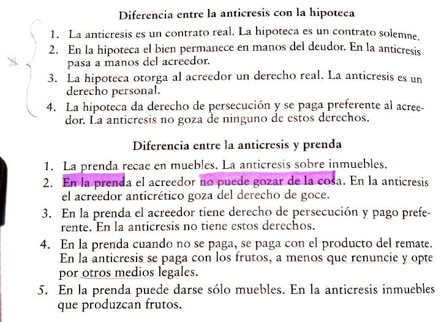

    Diferencias Anticresis

- El Contrato de Transacción

  Características:
  - ppal
  - consensual
  - bilateral
  - intuito personae
  - oneroso
  - puede o no ser TTD
  - debe existir un derecho dudoso y concesiones o sacrificios recíprocos

  Efectos:
  - equivalente jurisdiccional
  - sólo respecto de las partes
  - sólo respecto a objetos específicos
  - es obligatoria
  - produce efecto de cosa juzgada
- El Juego y la Apuesta

  ppales contratos aleatorios:
  - ctto. de seguro
  - préstamo a la gruesa ventura
  - juego
  - apuesta
  - constitución de renta vitalicia
  - constitución de censo vitalicio
- La Renta Vitalicia

  Características:
  - es un ctto real
  - aleatorio
  - ppal
  - unilateral
  - oneroso
- El censo

  Características
  - es un derecho real
  - contrato ppal
  - solemne
  - capital siempre en dinero o estimarse en dinero

  Constitución:
  - testamento
  - donación
  - venta

  Causales de extinción:
  - abandono que el censuario hace de la cosa a favor del censualista
  - redención del censo art. 2038
  - destrucción completa de la finca
  - prescripción
- El Contrato de Sociedad
  - Sociedad Colectiva

  Es aquella en que todos los socios administran por sí o por un mandatario elegido de común acuerdo. Su administración puede confiarse a uno o más socios, sea por el contrato de sociedad o por un acto posterior.
  - Características:
    - consensual, salvo las sociedades comerciales y las civiles de responsabilidad limitada
    - es intuito personae
    - bilateral
    - oneroso
    - conmutativo

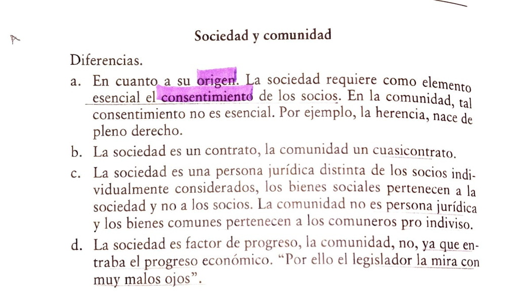

  Elementos:
  - aporte
  - participación en las utilidades
  - contribución en las pérdidas
  - intención de formar una sociedad

  Disolución:
  - expiración del plazo o evento de una condición
  - al finalizar el negocio para la cual fue contraída
  - insolvencia
  - pérdida de los bienes sociales
  - incumplimiento de la obligación de realizar el aporte
  - muerte de uno de los socios
- Contrato de Depósito

  Características:
  - contrato real
  - unilateral
  - por rg. es gratuito
  - contrato ppal.

  Obligaciones del depositario:
  - guardar y cuidar la cosa
    - responde de culpa grave
  - restituir la cosa a requerimiento del depositante
- El Comodato

  Características:
  - ctto unilateral
  - gratuito
  - real
  - es un título de mera tenencia
  - puede probarse por testigos
  - es ppal
  - comodatario responde de culpa levísima

  Obligaciones del comodatario:
  - debe cuidar la cosa con la máxima diligencia, responde de culpa levísima
  - usar la cosa según el uso autorizado en el ctto
  - su infracción genera la obligación de indemnizar y autoriza para terminar el ctto de forma anticipada
  - debe restituir en el plazo establecido o al terminar su uso

  Obligaciones del comodante:
  - pagar las expensas y perjuicios
  - indemnizar perjuicios por mala calidad o condición de lla cosa prestada
- Mutuo o Préstamo de Consumo

  Características:
  - es un ctto real
  - TTD
  - unilateral
  - no hay obligación de custodia
  - naturalmente gratuito
  - ctto ppal
  - sólo sobre cosas fungibles

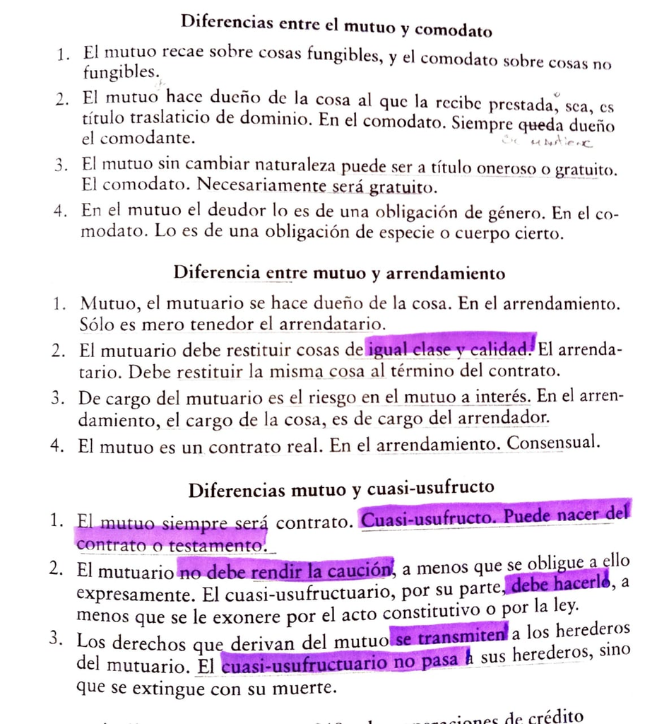

    Diferencias Mutuo

- Donación Revocable o entre vivos

  Pueden ser otorgados conforme a las normas de:
  - solemnidades del testamento
  - solemnidades de las donaciones entre vivos

  Tiene importancia respecto a su confirmación:
  - si es conforme al testamento quedará confirmada ipso iure con el fallecimiento
  - si es conforme a la donación entre vivos (reservándose la facultad de revocarla), será necesario que el causante confirme en el testamento.

## 6.3. Cuasicontratos

Esta institución reacciona frente al enriquecimiento injusto, otorgando el derecho de indemnización

Principales cuasicontratos (art. 2285): - Agencia Oficiosa - no debe existir mandato - debe actuar en interés del interesado - debe existir de parte del gestor, la intención de crear un vínculo obligatorio en el interesado - diferencias con el mandato: - mandato es un ctto - mandante debe ser capaz, el interesado no requiere serlo - mandatario se obliga independientemente del beneficio, el interesado se obliga con la condición de que la gestión le sea útil y en su medida - El Pago de lo No Debido - La Comunidad

```
Origen:
- en un hecho
- en un acto jurídico

Derechos de los comuneros:
- usar y gozar los bienes comunes
- derecho de oponerse a los actos de administración de otros
- derecho del comunero a enajenar su cuota

Obligaciones de los comuneros:
- contribuir a las expensas de conservación
- derecho a las innovaciones en los bienes comunes, con el consentimiento previo de los demás
- a hacer la partición cuando alguno lo pida
- los frutos se dividen a prorrata

Terminación de la comunidad:
- por la confusión de la cuota de todos los comuneros en una sola persona
- destrucción de la cosa común
- por la división del haber común
```

## 6.4. Delitos y Cuasidelito

Las obligaciones también nacen de un hecho que ha inferido injuria o daño a otra persona, como los delitos y cuasidelitos. Art. 1437.

Diferencias entre responsabilidad penal y civil - acción civil, acción penal - sanción penal es represiva, la civil es indemnizadora - distinta jurisdicción - capacidad penal 16-18, civil 7-16 - la penal es personalísima, la civil se transmite - acción penal prescribe de 6 meses a 15 años, la civil en 4 años

Diferencias entre responsabilidad contractual y extracontractual - contractual existe un vínculo jurídico preexistente - culpa contractual acepta graduaciones - capacidad contractual se adquiere a los 18 - en la extracontractual se presume la solidaridad - contractual prescribe en 5 años y la extracontractual en 4 años

Elementos de la responsabilidad: - daño - dolo o culpa - hechos que alteran o eximen la responsabilidad: - caso fortuito - estado de necesidad - hecho de un tercero - culpa de la víctima - eximentes de la responsabilidad - convenciones sobre responsabilidad extracontractual - relación de causalidad - capacidad

# 7. Derechos de Familia

- El Matrimonio

  Requisitos:
  - de existencia
    - diversidad de sexo
    - consentimiento
    - presencia del oficial del RC
  - de validez
    - ambos sean legalmente capaces
    - que hayan consentido libre y espontáneamente

  Impedimentos:
  - dirimentes - obstan al matrimonio (nulidad)
    - absolutos (respecto a cualquier personas)
      - hallarse ligado por vínculo matrimonial no disuelto
      - menores de 16 años
      - hallarse privado del uso de la razón, trastorno o anomalía psíquica, sea incapaz de modo absoluto de formar comunidad de vida que implica el matrimonio
      - los que carecen de suficiente juicio o discernimiento para comprender y comprometerse en matrimonio
      - los que no pudieren expresar claramente su voluntad por cualquier medio
    - relativos
      - por parentesco
      - por homicidio
  - impedientes (o prohibiciones)
    - por falta de asenso o licencia
    - de guarda, entre pupilos y guardadores
    - de segundas nupcias, respecto de los hijos de precedente matrimonio

  Formalidades:
  - Matrimonios celebrados en Chile
    - la manifestación o comunicación
    - la información
    - la celebración

      plazo de 90 días para celebrarse
    - posteriores a la celebración:
      - acta de todo lo obrado, firmada por el oficial, los contrayentes y testigos
      - se inscribirá los libros correspondientes
      - omisión no acarrea nulidad
  - Matrimonio celebrado en el extranjero

    art. 80 LMC, los requisitos de forma y de fondo del matrimonio serán los que establezca la ley **del lugar** de su celebración.
  - Matrimonios celebrados ante entidades religiosas de derecho público

    Producirán los mismos efectos que el matrimonio civil, siempre que cumplan con los requisitos contemplados en la ley, desde su inscripción

    Formalidades:
    - otorgamiento de acta
    - plazo de 8 días para su inscripción
  - Efectos del matrimonio
    - crea un conjunto de derechos y obligaciones
    - genera una sociedad universal que comprende los patrimonios de los cónyuges
    - da origen a la filiación matrimonial
    - crea entre los cónyuges la obligación de prestarse pensiones alimenticias
    - transforma a los cónyuges en herederos recíprocos
    - derecho a solicitar la declaración de bienes familiares
  - Terminación del matrimonio
    - muerte natural de un cónyuge
    - muerte presunta
    - sentencia firme que declara la nulidad del matrimonio
    - sentencia firme de divorcio
    - sentencia firme que acoge la rectificación de sexo y nombre por razón de identidad de género
- Separación
  - Separación de Hecho

    Mera separación de cuerpos, cuyo objeto es regular especialmente la materia de alimentos, régimen de bienes y en su caso el cuidado personal y la relación directa y regular
    - si no hubo prole:
      - regular sus relaciones mutuas
      - los alimentos
      - régimen de bienes del matrimonio
    - si hubo:
      - regular además el régimen aplicable a los alimentos
      - cuidado personal y a la relación directa y regular que mantendrá con los hijos aquél que no tuviere bajo su cuidado
    - Formas de regular:
      - de común acuerdo
        - Formalidades (para dar fecha cierta al cese de convivencia)
          - Escritura pública
          - acta extendida y protocolizada ante notario
          - acta extendida ante oficial del RC
          - transacción aprobada judicialmente
          - notificación de la demanda, caso del art. 23

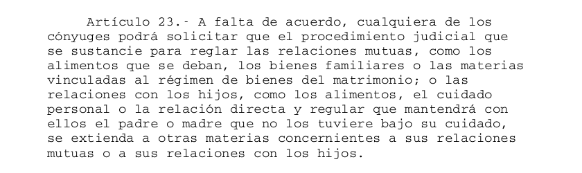

      - regulación judicial

        En forma subsidiaria
  - Separación Judicial
    - por uno de los cónyuges si hay falta imputable al otro

      Es una acción irrenunciable
    - por cualquiera si hay cese de convivencia
    - de forma conjunta, acompañando acuerdo completo y suficiente

    Efectos de la separación judicial:
    - desde que se dicta la sentencia y quede ejecutoriada
    - no pueden casarse
    - subsisten todos los derechos y obligaciones personales
    - terminan los regímenes matrimoniales
    - no se alteran los derechos hereditarios
    - no alteran la filiación
    - no goza de presunción de paternidad
- Nulidad del Matrimonio

  Causales:
  - por alguna de las incapacidades señaladas en los art. 5,6,7
    - ligados por vínculo matrimonial no disuelto
    - menores de 16
    - privados de razón
    - carecer de suficiente juicio o discernimiento
    - no poder expresar claramente su voluntad
    - por parentesco (ascendientes y descendientes, por consanguinidad o afinidad, ni los colaterales por consanguinidad en 2do grado)
    - el caso del homicidio del cónyuge(formalizado o condenado)
  - consentimiento no hubiere sido libre y espontáneo
  - no celebrado ante el número de testigos hábiles
  - Titularidad

    Corresponde a cualquiera de los cónyuges, salvo:
    - menores de 16 = solamente los que contrajeron sin tener la edad exigida = dentro de 1 año, empieza a correr una vez cumplida la mayoría de edad
    - error o fuerza = solamente el que las han sufrido = 3 años, desde que hubiere desaparecido el hecho que origina el vicio
    - matrimonio celebrado en art. de muerte = también corresponde a los herederos del difunto = 1 año desde el fallecimiento
    - vínculo matrimonial no disuelto = también al cónyuge anterior o sus herederos = 1 año al fallecimiento de uno de los cónyuges
    - por parentesco u homicidio = también por cualquier persona con interés en la moral o de la ley = 1 año desde la celebración del matrimonio

  Efectos de la declaración de nulidad
  - retroactivamente
  - debe subinscribirse al margen de la respectiva inscripción matrimonial
  - si uno de los cónyuges hubiese contraído matrimonio nuevamente, es válido
  - las capitulaciones matrimoniales caducan
  - no ha habido sociedad conyugal ni participación en los gananciales
  - no ha habido parentesco por afinidad
  - los hijos son matrimoniales
  - se presume que los cónyuges han contraído matrimonio de buena fe y justa causa de error
- El Divorcio
  - unilateral
    - atentado contra la vida o malos tratamientos graves contra la integridad física o psíquica del cónyuge o de algunos de los hijos
    - trasgresión grave y reiterada de los deberes de convivencia, socorro y fidelidad propios del matrimonio
    - condena ejecutoriada por la comisión de crímenes o simples delitos contra el orden de las familias y contra la moralidad pública
    - conducta homosexual
    - alcoholismo o drogadicción
    - tentativa de prostituir al otro o sus hijos
  - de común acuerdo
    - cese de convivencia mayor de 1 año
    - debe acompañarse acuerdo completo y suficiente
  - por trascurso del tiempo
    - 3 años de cese de convivencia
  - Efectos:
    - desde que la sentencia quede ejecutoriada
    - deberá subinscribirse
    - crea el estado civil de divorciado
    - pone fin a las obligaciones y derechos de carácter patrimonial que se fundan en el matrimonio
  - Reglas comunes a la separación, nulidad y divorcio
    - Compensación económica
    - Conciliación

# 8. Derecho Sucesorio